# Session 6: Homework 3- Group A8

Aditi Lapasia, Diego Alfaro Legonia, Edgar Pon, Ivy Liu, Teen Ho Nicholas Ching, Roberto Keaney, Susan Wang

9th October 2021

# 1 Youth Risk Behavior Surveillance

Every two years, the Centers for Disease Control and Prevention conduct the [Youth Risk Behavior Surveillance System (YRBSS)](https://www.cdc.gov/healthyyouth/data/yrbs/index.htm) survey, where it takes data from high schoolers (9th through 12th grade), to analyze health patterns. You will work with a selected group of variables from a random sample of observations during one of the years the YRBSS was conducted.

## 1.1 Load the data

This data is part of the `openintro` textbook and we can load and inspect it. There are observations on 13 different variables, some categorical and some numerical.

```r
data(yrbss)
glimpse(yrbss)
```

```
## Rows: 13,583
## Columns: 13
## $ age                      <int> 14, 14, 15, 15, 15, 15, 15, 14, 15, 15, 15, 1~
## $ gender                   <chr> "female", "female", "female", "female", "fema~
## $ grade                    <chr> "9", "9", "9", "9", "9", "9", "9", "9", "9", ~
## $ hispanic                 <chr> "not", "not", "hispanic", "not", "not", "not"~
## $ race                     <chr> "Black or African American", "Black or Africa~
## $ height                   <dbl> NA, NA, 1.73, 1.60, 1.50, 1.57, 1.65, 1.88, 1~
## $ weight                   <dbl> NA, NA, 84.4, 55.8, 46.7, 67.1, 131.5, 71.2, ~
## $ helmet_12m               <chr> "never", "never", "never", "never", "did not ~
## $ text_while_driving_30d   <chr> "0", NA, "30", "0", "did not drive", "did not~
## $ physically_active_7d     <int> 4, 2, 7, 0, 2, 1, 4, 4, 5, 0, 0, 0, 4, 7, 7, ~
## $ hours_tv_per_school_day  <chr> "5+", "5+", "5+", "2", "3", "5+", "5+", "5+",~
## $ strength_training_7d     <int> 0, 0, 0, 0, 1, 0, 2, 0, 3, 0, 3, 0, 0, 7, 7, ~
## $ school_night_hours_sleep <chr> "8", "6", "<5", "6", "9", "8", "9", "6", "<5"~
```

Before you carry on with your analysis, it’s is always a good idea to check with `skimr::skim()` to get a feel for missing values, summary statistics of numerical variables, and a very rough histogram.

## 1.2 Exploratory Data Analysis

You will first start with analyzing the `weight` of participants in kilograms. Using visualization and summary statistics, describe the distribution of weights. How many observations are we missing weights from?

```r
skimr::skim(yrbss) # 1004 missing in weight
```

Data summary

| Name | yrbss |
| --- | --- |
| Number of rows | 13583 |
| Number of columns | 13 |
| _______________________ |  |
| Column type frequency: |  |
| character | 8 |
| numeric | 5 |
| ________________________ |  |
| Group variables | None |

**Variable type: character**

| skim_variable | n_missing | complete_rate | min | max | empty | n_unique | whitespace |
| --- | --- | --- | --- | --- | --- | --- | --- |
| gender | 12 | 1.00 | 4 | 6 | 0 | 2 | 0 |
| grade | 79 | 0.99 | 1 | 5 | 0 | 5 | 0 |
| hispanic | 231 | 0.98 | 3 | 8 | 0 | 2 | 0 |
| race | 2805 | 0.79 | 5 | 41 | 0 | 5 | 0 |
| helmet_12m | 311 | 0.98 | 5 | 12 | 0 | 6 | 0 |
| text_while_driving_30d | 918 | 0.93 | 1 | 13 | 0 | 8 | 0 |
| hours_tv_per_school_day | 338 | 0.98 | 1 | 12 | 0 | 7 | 0 |
| school_night_hours_sleep | 1248 | 0.91 | 1 | 3 | 0 | 7 | 0 |

**Variable type: numeric**

| skim_variable | n_missing | complete_rate | mean | sd | p0 | p25 | p50 | p75 | p100 | hist |
| --- | --- | --- | --- | --- | --- | --- | --- | --- | --- | --- |
| age | 77 | 0.99 | 16.16 | 1.26 | 12.00 | 15.0 | 16.00 | 17.00 | 18.00 | ▁▂▅▅▇ |
| height | 1004 | 0.93 | 1.69 | 0.10 | 1.27 | 1.6 | 1.68 | 1.78 | 2.11 | ▁▅▇▃▁ |
| weight | 1004 | 0.93 | 67.91 | 16.90 | 29.94 | 56.2 | 64.41 | 76.20 | 180.99 | ▆▇▂▁▁ |
| physically_active_7d | 273 | 0.98 | 3.90 | 2.56 | 0.00 | 2.0 | 4.00 | 7.00 | 7.00 | ▆▂▅▃▇ |
| strength_training_7d | 1176 | 0.91 | 2.95 | 2.58 | 0.00 | 0.0 | 3.00 | 5.00 | 7.00 | ▇▂▅▂▅ |

```r
favstats(~weight, data = yrbss)
```

```
##   min   Q1 median   Q3 max mean   sd     n missing
##  29.9 56.2   64.4 76.2 181 67.9 16.9 12579    1004
```

```r
yrbss_new <- yrbss %>%
             na.omit() %>%
             mutate(physical_3plus = ifelse(physically_active_7d > 2,"yes","no"))

favstats(weight~physical_3plus, data = yrbss_new)
```

```
##   physical_3plus  min   Q1 median   Q3 max mean   sd    n missing
## 1             no 31.8 54.4   62.6 74.8 181 67.1 18.0 2656       0
## 2            yes 35.4 56.7   65.8 77.1 160 68.7 16.4 5695       0
```

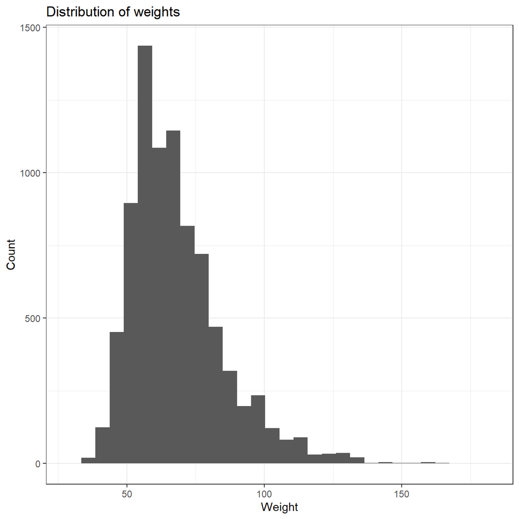

```r
ggplot(yrbss_new,aes(x = weight)) +
  geom_histogram() +
  theme_bw() +
  labs(title = "Distribution of weights",
       x = "Weight",
       y = "Count")
```

Comment: The previous graph displays a distribution of body weight. The graph is not normally distributed but skewed to the right. This can be explained by the fact that in most countries there is a standard weight range depending on the height of the person. The more extreme results are seen on the right end of the distribution, as it’s more common to have people who are severely overweight than people who are severely underweight.

Next, consider the possible relationship between a high schooler’s weight and their physical activity. Plotting the data is a useful first step because it helps us quickly visualize trends, identify strong associations, and develop research questions.

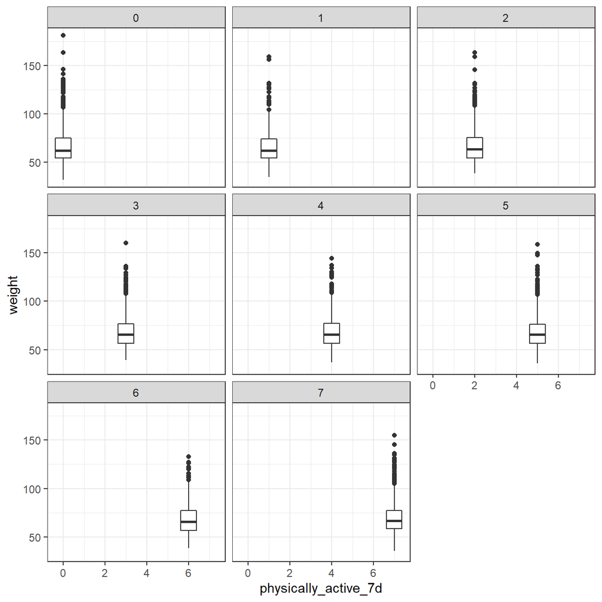

```r
ggplot(yrbss_new, aes(x = physically_active_7d, y = weight)) +
  geom_boxplot() +
  theme_bw() +
  facet_wrap(~physically_active_7d)
```

Comment: The distribution of high schoolers’ weight depending on the number of days a week they exercise indicates that there’s a positive correlation among both variables. Although many believe that higher amounts of exercise lead to lower body weight, the opposite is true, particularly for high schoolers’ who exercise 6 or 7 days per week. People of a young age that exercise regularly tend to be athletes, and athletes tend to have a large amount of body muscle. It is reasonable to assume that these high schoolers’ are stronger and by that account to weigh more than the average high schooler.

High schoolers’ that do not exercise anytime throughout the week tend to have more extreme body weight when compared to others that do even once or twice a week. Even moderate exercise can have a significant impact on your overall health and high schoolers’ that do exercise and less likely to have extremely high levels of body weight.

You may also want to calculate the number and % of those who are and are not active for more than 3 days. Use the `count()` function and see if you get the same results as `group_by()... summarise()`

```r
proportion <- yrbss_new %>%
              group_by(physical_3plus) %>%
              summarise(number_2 = count(physical_3plus)) %>%
              mutate(sum_2 = sum(number_2),
                     percent_2 = number_2/sum_2)

proportion
```

```
## # A tibble: 2 x 4
##   physical_3plus number_2 sum_2 percent_2
##   <chr>             <int> <int>     <dbl>
## 1 no                 2656  8351     0.318
## 2 yes                5695  8351     0.682
```

Can you provide a 95% confidence interval for the population proportion of high schools that are *NOT* active 3 or more days per week?

```r
ci_formula_proportion <- proportion %>%
  filter(physical_3plus == "no") %>%
  summarise(not_active_proportion = percent_2,
            n = sum_2,
            t_critical = qt(0.975,n-1),
            SE_proportion = sqrt(not_active_proportion * (1 - not_active_proportion)/n),
            CI_proportion_low = not_active_proportion - t_critical * SE_proportion,
            CI_proportion_high = not_active_proportion + t_critical * SE_proportion)

ci_formula_proportion
```

```
## # A tibble: 1 x 6
##   not_active_proportion     n t_critical SE_proportion CI_proportion_low
##                   <dbl> <int>      <dbl>         <dbl>             <dbl>
## 1                 0.318  8351       1.96       0.00510             0.308
## # ... with 1 more variable: CI_proportion_high <dbl>
```

Make a boxplot of `physical_3plus` vs. `weight`. Is there a relationship between these two variables? What did you expect and why?

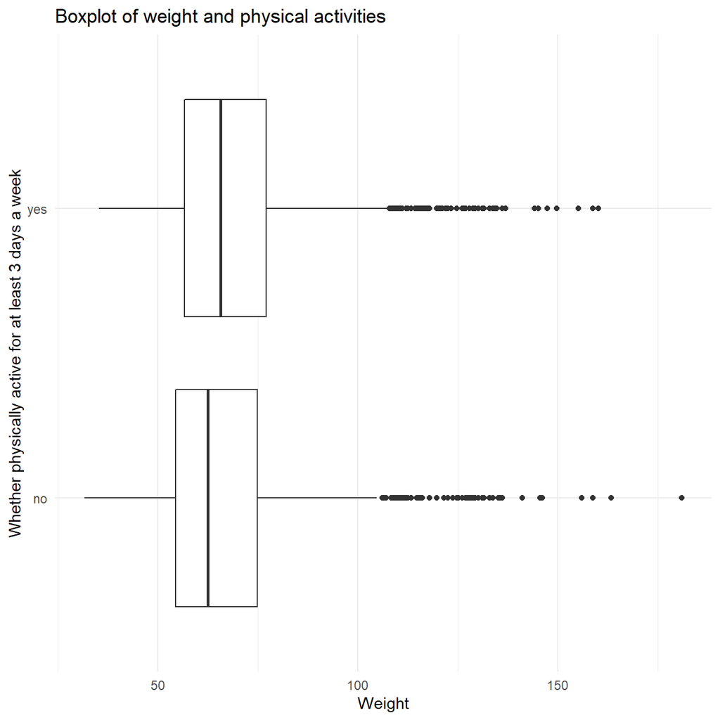

```r
ggplot(yrbss_new, aes (x = weight, y = physical_3plus))+
  geom_boxplot()+
  theme_minimal()+
  labs(title = "Boxplot of weight and physical activities",
       x = "Weight",
       y = "Whether physically active for at least 3 days a week")+
  NULL
```

Comment: The relationship between body weight and performing physical exercise 3 more days per week is slightly positive. Referring back to the argument stated previously, high levels of physical activity encourage muscle growth, which weighs more than body fat. Also, people who tend to exercise a lot perceive higher levels of cortisol. Although cortisol is strongly related to stress, it has been proven to increase weight and also create additional belly fat, even with lean people.

On the other hand, the differences among both results is negligible and there is no clear trend as to how 3 more days per week impacts a high schoolers’ body weight.

## 1.3 Confidence Interval

Boxplots show how the medians of the two distributions compare, but we can also compare the means of the distributions using either a confidence interval or a hypothesis test. Note that when we calculate the mean, SD, etc. weight in these groups using the mean function, we must ignore any missing values by setting the `na.rm = TRUE`.

```r
ci_formula <- yrbss_new %>%
  group_by(physical_3plus) %>%
  summarise(mean_weight = mean(weight,na.rm = TRUE),
            sd_weight = sd(weight),
            count = n(),
            t_critical = qt(0.975,count-1),
            se_weight = sd(weight)/sqrt(count),
            margin_of_error = t_critical*se_weight,
            weight_low = mean_weight - margin_of_error,
            weight_high = mean_weight + margin_of_error)

ci_formula
```

```
## # A tibble: 2 x 9
##   physical_3plus mean_weight sd_weight count t_critical se_weight
##   <chr>                <dbl>     <dbl> <int>      <dbl>     <dbl>
## 1 no                    67.1      18.0  2656       1.96     0.349
## 2 yes                   68.7      16.4  5695       1.96     0.218
## # ... with 3 more variables: margin_of_error <dbl>, weight_low <dbl>,
## #   weight_high <dbl>
```

## 1.4 Hypothesis test with formula

Write the null and alternative hypotheses for testing whether mean weights are different for those who exercise at least times a week and those who don’t.

H0: mean weights are NOT different for those who exercise at least 3 times a week from those who don’t H1: mean weights are different for those who exercise at least times a week from those who don’t

```r
t.test(weight ~ physical_3plus, data = yrbss_new)
```

```
##
##  Welch Two Sample t-test
##
## data:  weight by physical_3plus
## t = -4, df = 4781, p-value = 2e-04
## alternative hypothesis: true difference in means between group no and group yes is not equal to 0
## 95 percent confidence interval:
##  -2.334 -0.721
## sample estimates:
##  mean in group no mean in group yes
##              67.1              68.7
```

```r
# From the p-value(which is extremely small) and the CI(which does not contain 0), we have reason to reject the null hypothesis
```

## 1.5 Hypothesis test with `infer`

Next, we will introduce a new function, `hypothesize`, that falls into the infer workflow. You will use this method for conducting hypothesis tests.

But first, we need to initialize the test, which we will save as `obs_diff`.

```r
obs_diff <- yrbss_new %>%
            specify(weight ~ physical_3plus) %>%
            calculate(stat = "diff in means", order = c("yes", "no"))
```

Notice how you can use the functions specify and calculate again like you did for calculating confidence intervals. Here, though, the statistic you are searching for is the difference in means, with the order being yes - no != 0.

After you have initialized the test, you need to simulate the test on the null distribution, which we will save as null.

```r
null_dist <- yrbss_new %>%
  # specify variables
  specify(weight ~ physical_3plus) %>%

  # assume independence, i.e, there is no difference
  hypothesize(null = "independence") %>%

  # generate 1000 reps, of type "permute"
  generate(reps = 1000, type = "permute") %>%

  # calculate statistic of difference, namely "diff in means"
  calculate(stat = "diff in means", order = c("yes", "no"))

null_dist
```

```
## Response: weight (numeric)
## Explanatory: physical_3plus (factor)
## Null Hypothesis: independence
## # A tibble: 1,000 x 2
##    replicate     stat
##        <int>    <dbl>
##  1         1  0.0585
##  2         2 -0.450
##  3         3 -0.297
##  4         4  0.00690
##  5         5  0.485
##  6         6 -0.690
##  7         7  0.365
##  8         8  0.891
##  9         9 -0.256
## 10        10 -1.04
## # ... with 990 more rows
```

Here, `hypothesize` is used to set the null hypothesis as a test for independence, i.e., that there is no difference between the two population means. In one sample cases, the null argument can be set to *point* to test a hypothesis relative to a point estimate.

Also, note that the `type` argument within generate is set to permute, which is the argument when generating a null distribution for a hypothesis test.

We can visualize this null distribution with the following code:

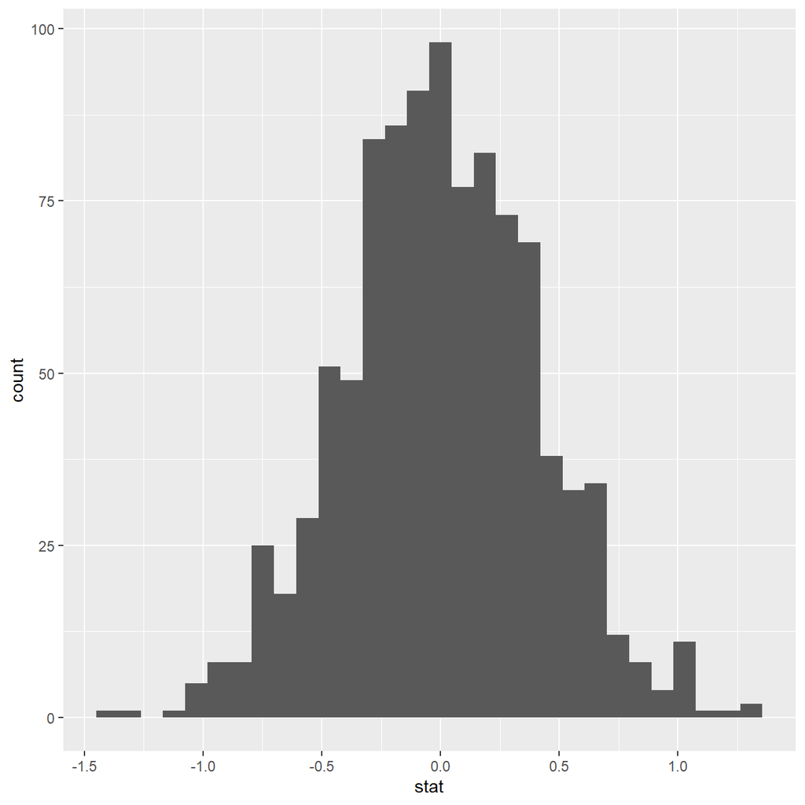

```r
ggplot(data = null_dist, aes(x = stat)) +
  geom_histogram()
```

Now that the test is initialized and the null distribution formed, we can visualise to see how many of these null permutations have a difference of at least `obs_stat` of 1.53?

We can also calculate the p-value for your hypothesis test using the function `infer::get_p_value()`.

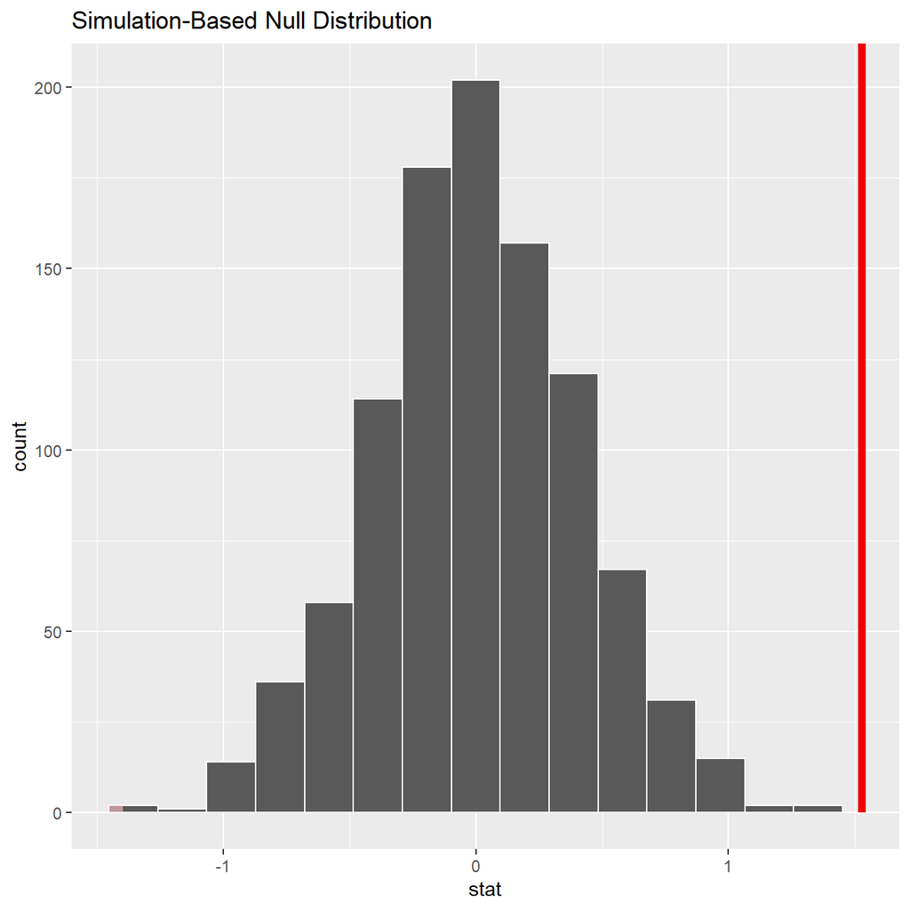

```r
null_dist %>% visualize() +
  shade_p_value(obs_stat = obs_diff, direction = "two-sided")
```

```r
null_dist %>%
  get_p_value(obs_stat = obs_diff, direction = "two_sided")
```

```
## # A tibble: 1 x 1
##   p_value
##     <dbl>
## 1       0
```

Comment: The null distribution is the probability distribution of the test statistic when the null hypothesis is true. The previous graph displays the visual representation of the null distribution.

This the standard workflow for performing hypothesis tests.

# 2 IMDB ratings: Differences between directors

Recall the IMBD ratings data. I would like you to explore whether the mean IMDB rating for Steven Spielberg and Tim Burton are the same or not. I have already calculated the confidence intervals for the mean ratings of these two directors and as you can see they overlap.

> Before anything, write down the null and alternative hypotheses, as well as the resulting test statistic and the associated t-stat or p-value. At the end of the day, what do you conclude?

H0: The mean IMDB rating for Steven Spielberg and Tim Burton are the same H1: The mean IMDB rating for Steven Spielberg and Tim Burton are different

Reject the H0.

You can load the data and examine its structure

```r
movies <- read_csv(here::here("data", "movies.csv"))
glimpse(movies)
```

```
## Rows: 2,961
## Columns: 11
## $ title               <chr> "Avatar", "Titanic", "Jurassic World", "The Avenge~
## $ genre               <chr> "Action", "Drama", "Action", "Action", "Action", "~
## $ director            <chr> "James Cameron", "James Cameron", "Colin Trevorrow~
## $ year                <dbl> 2009, 1997, 2015, 2012, 2008, 1999, 1977, 2015, 20~
## $ duration            <dbl> 178, 194, 124, 173, 152, 136, 125, 141, 164, 93, 1~
## $ gross               <dbl> 7.61e+08, 6.59e+08, 6.52e+08, 6.23e+08, 5.33e+08, ~
## $ budget              <dbl> 2.37e+08, 2.00e+08, 1.50e+08, 2.20e+08, 1.85e+08, ~
## $ cast_facebook_likes <dbl> 4834, 45223, 8458, 87697, 57802, 37723, 13485, 920~
## $ votes               <dbl> 886204, 793059, 418214, 995415, 1676169, 534658, 9~
## $ reviews             <dbl> 3777, 2843, 1934, 2425, 5312, 3917, 1752, 1752, 35~
## $ rating              <dbl> 7.9, 7.7, 7.0, 8.1, 9.0, 6.5, 8.7, 7.5, 8.5, 7.2, ~
```

```r
skimr::skim(movies)
```

Data summary

| Name | movies |
| --- | --- |
| Number of rows | 2961 |
| Number of columns | 11 |
| _______________________ |  |
| Column type frequency: |  |
| character | 3 |
| numeric | 8 |
| ________________________ |  |
| Group variables | None |

**Variable type: character**

| skim_variable | n_missing | complete_rate | min | max | empty | n_unique | whitespace |
| --- | --- | --- | --- | --- | --- | --- | --- |
| title | 0 | 1 | 1 | 83 | 0 | 2907 | 0 |
| genre | 0 | 1 | 5 | 11 | 0 | 17 | 0 |
| director | 0 | 1 | 3 | 32 | 0 | 1366 | 0 |

**Variable type: numeric**

| skim_variable | n_missing | complete_rate | mean | sd | p0 | p25 | p50 | p75 | p100 | hist |
| --- | --- | --- | --- | --- | --- | --- | --- | --- | --- | --- |
| year | 0 | 1 | 2.00e+03 | 9.95e+00 | 1920.0 | 2.00e+03 | 2.00e+03 | 2.01e+03 | 2.02e+03 | ▁▁▁▂▇ |
| duration | 0 | 1 | 1.10e+02 | 2.22e+01 | 37.0 | 9.50e+01 | 1.06e+02 | 1.19e+02 | 3.30e+02 | ▃▇▁▁▁ |
| gross | 0 | 1 | 5.81e+07 | 7.25e+07 | 703.0 | 1.23e+07 | 3.47e+07 | 7.56e+07 | 7.61e+08 | ▇▁▁▁▁ |
| budget | 0 | 1 | 4.06e+07 | 4.37e+07 | 218.0 | 1.10e+07 | 2.60e+07 | 5.50e+07 | 3.00e+08 | ▇▂▁▁▁ |
| cast_facebook_likes | 0 | 1 | 1.24e+04 | 2.05e+04 | 0.0 | 2.24e+03 | 4.60e+03 | 1.69e+04 | 6.57e+05 | ▇▁▁▁▁ |
| votes | 0 | 1 | 1.09e+05 | 1.58e+05 | 5.0 | 1.99e+04 | 5.57e+04 | 1.33e+05 | 1.69e+06 | ▇▁▁▁▁ |
| reviews | 0 | 1 | 5.03e+02 | 4.94e+02 | 2.0 | 1.99e+02 | 3.64e+02 | 6.31e+02 | 5.31e+03 | ▇▁▁▁▁ |
| rating | 0 | 1 | 6.39e+00 | 1.05e+00 | 1.6 | 5.80e+00 | 6.50e+00 | 7.10e+00 | 9.30e+00 | ▁▁▆▇▁ |

```r
movies_new <- movies %>%
  filter(director %in% c("Steven Spielberg","Tim Burton"))

ci_formula_movie <- movies_new %>%
  group_by(director) %>%
  summarise(mean_rating = mean(rating,na.rm = TRUE),
            sd_rating = sd(rating),
            count = n(),
            t_critical = qt(0.975,count-1),
            se_rating = sd(rating)/sqrt(count),
            margin_of_error = t_critical*se_rating,
            rating_low = mean_rating - margin_of_error,
            rating_high = mean_rating + margin_of_error) %>%
  arrange(desc(mean_rating))

ci_formula_movie
```

```
## # A tibble: 2 x 9
##   director         mean_rating sd_rating count t_critical se_rating margin_of_error
##   <chr>                  <dbl>     <dbl> <int>      <dbl>     <dbl>           <dbl>
## 1 Steven Spielberg        7.57     0.695    23       2.07     0.145           0.301
## 2 Tim Burton              6.93     0.749    16       2.13     0.187           0.399
## # ... with 2 more variables: rating_low <dbl>, rating_high <dbl>
```

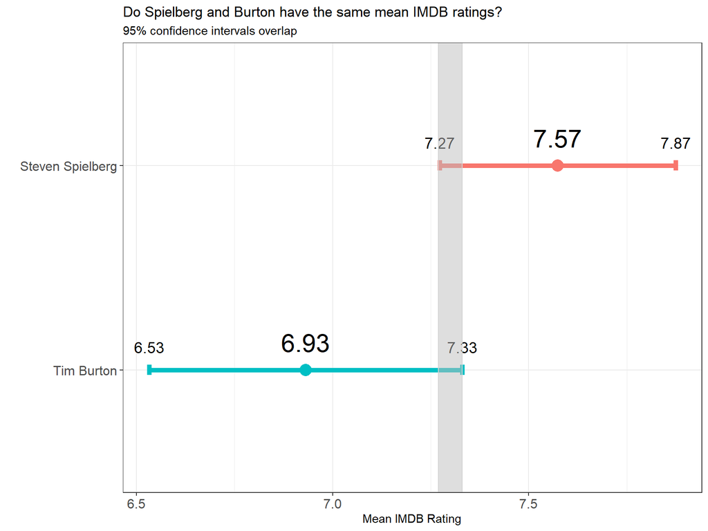

```r
ggplot(ci_formula_movie,aes(x = mean_rating, y = reorder(director,mean_rating), color = director))+
  geom_point(size = 5)+
  geom_errorbar(aes(xmin = rating_low, xmax = rating_high),
                width = 0.05,size = 2)+
  theme_bw()+
  theme(legend.position = "none",
        axis.text = element_text(size = 12))+
  geom_text(aes(label=round(mean_rating,2)),vjust = -1,color = "black",size = 8) +
  geom_text(aes(label=round(rating_low,2),x = rating_low),vjust = -1.5,color = "black",size = 5) +
  geom_text(aes(label=round(rating_high,2),x = rating_high),vjust = -1.5, color = "black",size = 5) +
  geom_rect(xmin = 7.27,xmax = 7.33, ymin = 0, ymax = 4, color = "lightgrey", fill = "grey",alpha = 0.3) +
  labs(title = "Do Spielberg and Burton have the same mean IMDB ratings?",
       subtitle = "95% confidence intervals overlap",
       x = "Mean IMDB Rating",
       y = " ")
```

Comment: The 95% confidence intervals for Spielberg’s and Burton’s films show a small overlap in the ratings between their films of 7.27 and 7.33. Accordingly, we can test whether these directors possessing the same IMDB ratings is just a coincidence using a simulation-based null distribution.

You will run a hypothesis test. You should use both the `t.test` command and the `infer` package to simulate from a null distribution, where you assume zero difference between the two.

```r
# Hypothesis test using R formula
movies_new <- movies %>%
  filter(director %in% c("Steven Spielberg","Tim Burton"))

t.test(rating ~ director, data = movies_new)
```

```
##
##  Welch Two Sample t-test
##
## data:  rating by director
## t = 3, df = 31, p-value = 0.01
## alternative hypothesis: true difference in means between group Steven Spielberg and group Tim Burton is not equal to 0
## 95 percent confidence interval:
##  0.16 1.13
## sample estimates:
## mean in group Steven Spielberg       mean in group Tim Burton
##                           7.57                           6.93
```

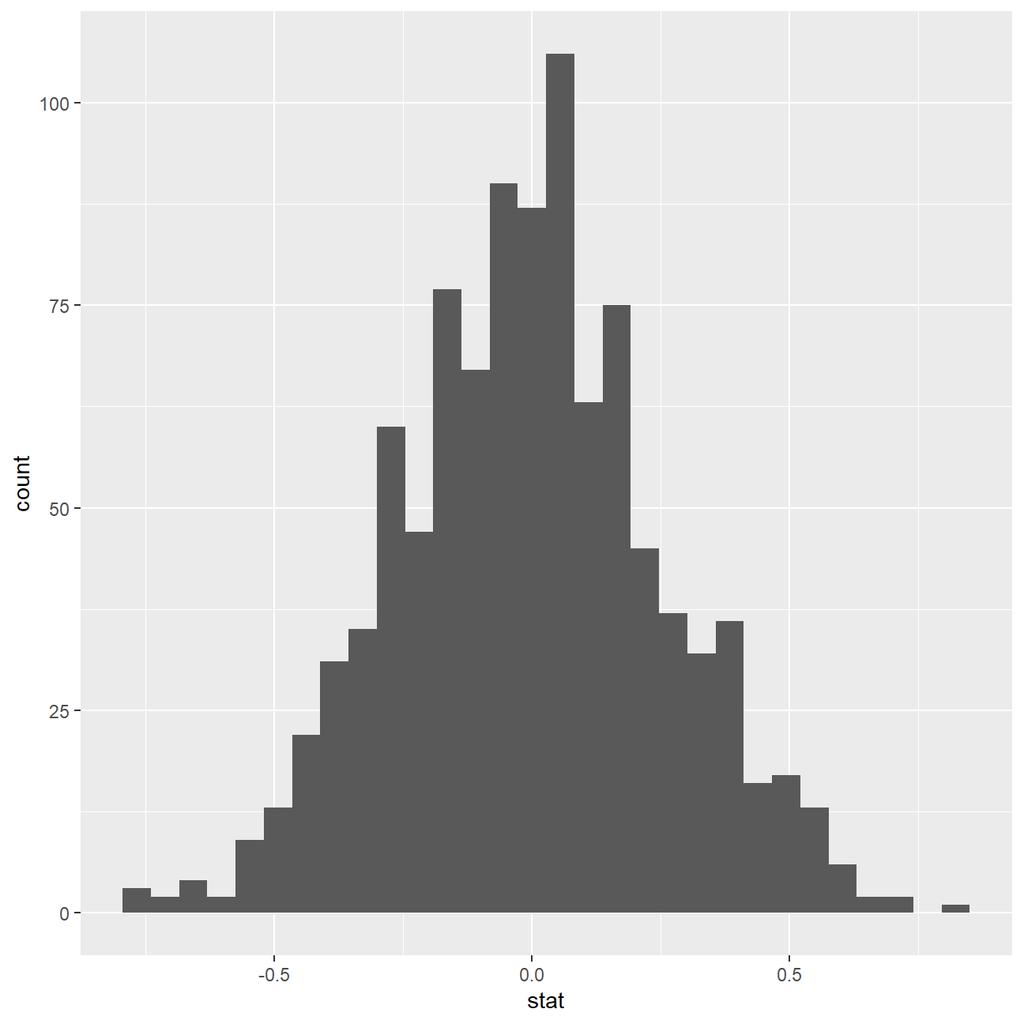

```r
# Hypothesis test using 'infer'
obs_diff_movie <- movies_new %>%
  specify(rating ~ director) %>%
  calculate(stat = "diff in means", order = c("Steven Spielberg", "Tim Burton"))

null_dist_movie <- movies_new %>%
  # specify variables
  specify(rating ~ director) %>%

  # assume independence, i.e, there is no difference
  hypothesize(null = "independence") %>%

  # generate 1000 reps, of type "permute"
  generate(reps = 1000, type = "permute") %>%

  # calculate statistic of difference, namely "diff in means"
  calculate(stat = "diff in means", order = c("Steven Spielberg", "Tim Burton"))

ggplot(data = null_dist_movie, aes(x = stat)) +
  geom_histogram()
```

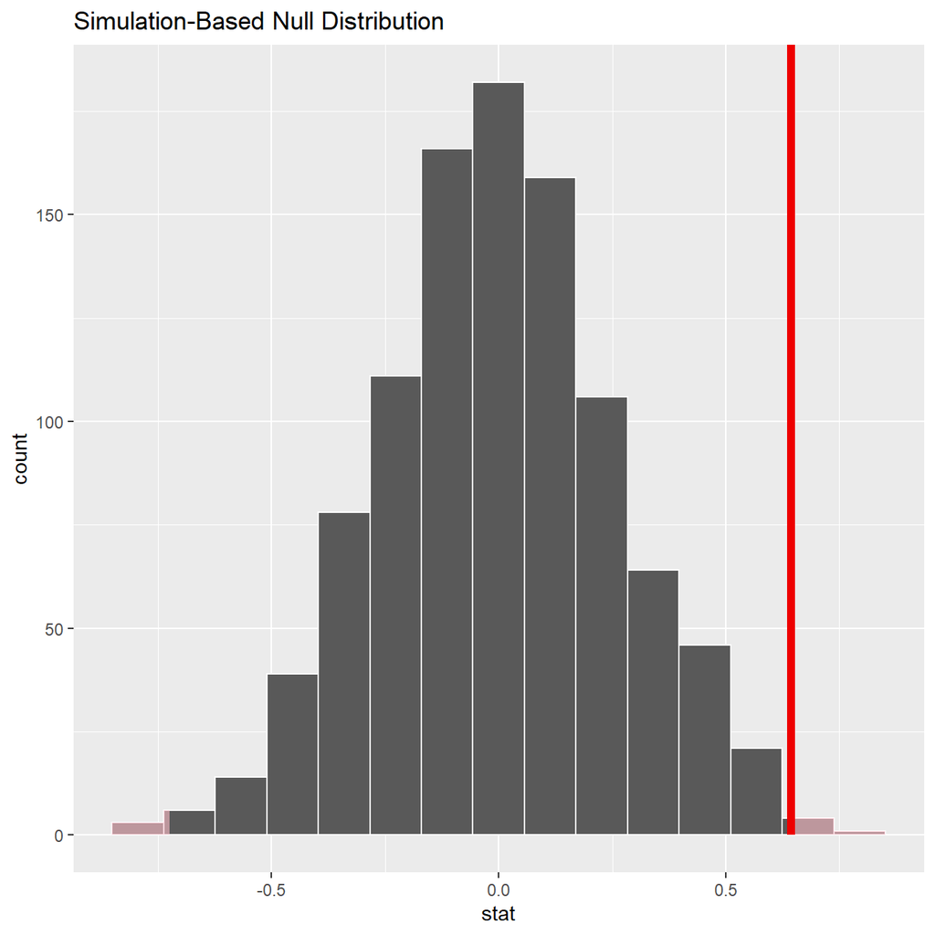

```r
null_dist_movie %>% visualize() +
  shade_p_value(obs_stat = obs_diff_movie, direction = "two-sided")
```

```r
null_dist_movie %>%
  get_p_value(obs_stat = obs_diff_movie, direction = "two_sided")
```

```
## # A tibble: 1 x 1
##   p_value
##     <dbl>
## 1    0.01
```

# 3 Omega Group plc- Pay Discrimination

At the last board meeting of Omega Group Plc., the headquarters of a large multinational company, the issue was raised that women were being discriminated in the company, in the sense that the salaries were not the same for male and female executives. A quick analysis of a sample of 50 employees (of which 24 men and 26 women) revealed that the average salary for men was about 8,700 higher than for women. This seemed like a considerable difference, so it was decided that a further analysis of the company salaries was warranted.

You are asked to carry out the analysis. The objective is to find out whether there is indeed a significant difference between the salaries of men and women, and whether the difference is due to discrimination or whether it is based on another, possibly valid, determining factor.

## 3.1 Loading the data

```r
omega <- read_csv(here::here("data", "omega.csv"))
glimpse(omega) # examine the data frame
```

```
## Rows: 50
## Columns: 3
## $ salary     <dbl> 81894, 69517, 68589, 74881, 65598, 76840, 78800, 70033, 635~
## $ gender     <chr> "male", "male", "male", "male", "male", "male", "male", "ma~
## $ experience <dbl> 16, 25, 15, 33, 16, 19, 32, 34, 1, 44, 7, 14, 33, 19, 24, 3~
```

## 3.2 Relationship Salary - Gender ?

The data frame `omega` contains the salaries for the sample of 50 executives in the company. Can you conclude that there is a significant difference between the salaries of the male and female executives? Comment: Analysing the data frame ‘omega’ for the salaries of 50 male and female executives, we can conclude that there is a significant difference between these salaries. The average male salary is 73,239, whereas the average female salary is 64,543. The mean female salary is around 1.17 standard deviations away from the mean male salary which shows a significant difference.

Note that you can perform different types of analyses, and check whether they all lead to the same conclusion

. Confidence intervals . Hypothesis testing . Correlation analysis . Regression

Calculate summary statistics on salary by gender. Also, create and print a dataframe where, for each gender, you show the mean, SD, sample size, the t-critical, the SE, the margin of error, and the low/high endpoints of a 95% confidence interval

```r
# Summary Statistics of salary by gender
mosaic::favstats (salary ~ gender, data=omega)
```

```
##   gender   min    Q1 median    Q3   max  mean   sd  n missing
## 1 female 47033 60338  64618 70033 78800 64543 7567 26       0
## 2   male 54768 68331  74675 78568 84576 73239 7463 24       0
```

```r
# Dataframe with two rows (male-female) and having as columns gender, mean, SD, sample size,
# the t-critical value, the standard error, the margin of error,
# and the low/high endpoints of a 95% condifence interval
ci_formula_omega <- omega %>%
  group_by(gender) %>%
  summarise(mean_salary_gender = mean(salary,na.rm = TRUE),
            sd_salary_gender = sd(salary),
            count = n(),
            t_critical = qt(0.975,count-1),
            se_salary_gender = sd(salary)/sqrt(count),
            margin_of_error = t_critical*se_salary_gender,
            salary_gender_low = mean_salary_gender - margin_of_error,
            salary_gender_high = mean_salary_gender + margin_of_error)
ci_formula_omega
```

```
## # A tibble: 2 x 9
##   gender mean_salary_gender sd_salary_gender count t_critical se_salary_gender
##   <chr>               <dbl>            <dbl> <int>      <dbl>            <dbl>
## 1 female             64543.            7567.    26       2.06            1484.
## 2 male               73239.            7463.    24       2.07            1523.
## # ... with 3 more variables: margin_of_error <dbl>, salary_gender_low <dbl>,
## #   salary_gender_high <dbl>
```

> What can you conclude from your analysis? A couple of sentences would be enough

Comment: In order to verify our claims, we can run a simulation-based null distribution to see the probability of the means being this dissimilar and to try to separate the signal from the noise. Indeed, running the null distribution verifies our claims as the p-value is very low so we reject the null hypothesis and can conclude that the differences in the salaries of male and female executives is not due to sampling error alone and that there is a marked difference in their salaries.

You can also run a hypothesis testing, assuming as a null hypothesis that the mean difference in salaries is zero, or that, on average, men and women make the same amount of money. You should tun your hypothesis testing using `t.test()` and with the simulation method from the `infer` package.

```r
# hypothesis testing using t.test()

t.test(salary ~ gender, data = omega)
```

```
##
##  Welch Two Sample t-test
##
## data:  salary by gender
## t = -4, df = 48, p-value = 2e-04
## alternative hypothesis: true difference in means between group female and group male is not equal to 0
## 95 percent confidence interval:
##  -12973  -4420
## sample estimates:
## mean in group female   mean in group male
##                64543                73239
```

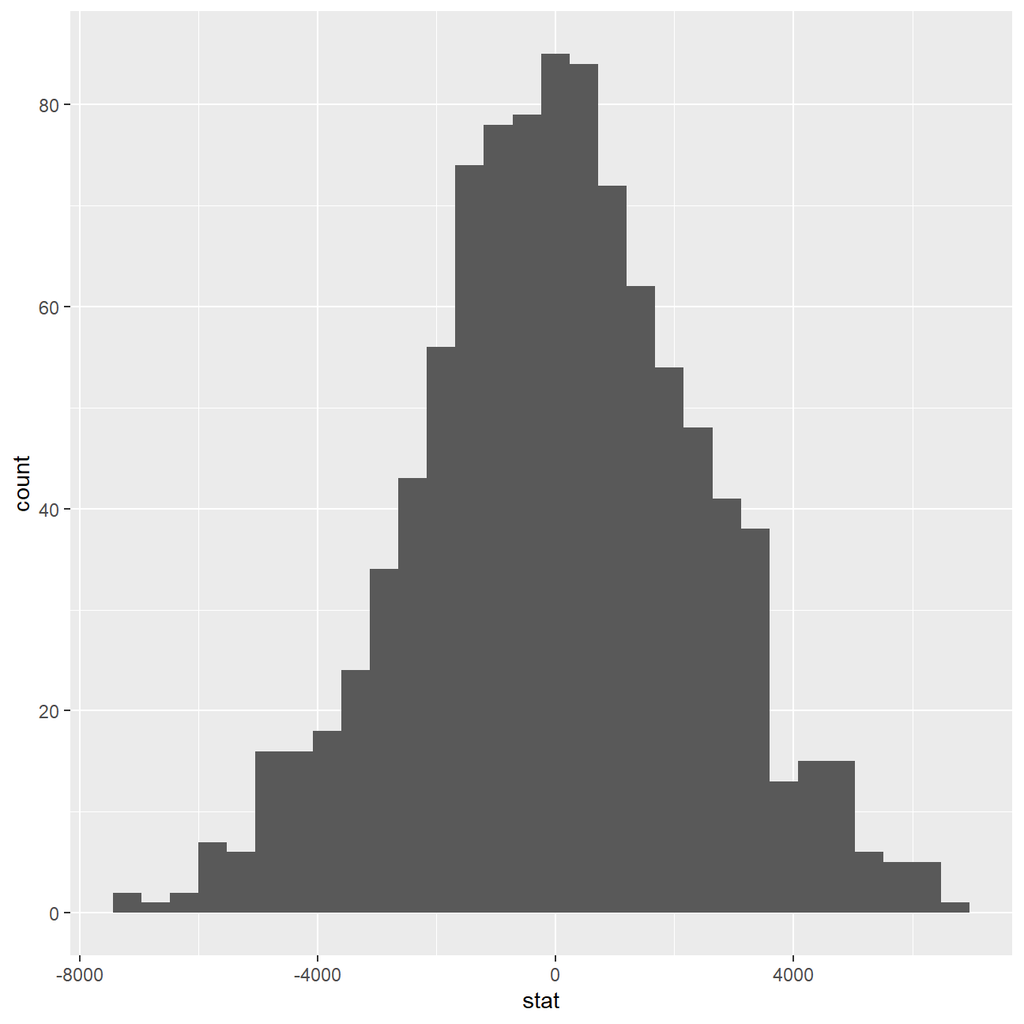

```r
# hypothesis testing using infer package
obs_diff_omega_1 <- omega %>%
  specify(salary ~ gender) %>%
  calculate(stat = "diff in means", order = c("male", "female"))

null_dist_omega_1 <- omega %>%
  # specify variables
  specify(salary ~ gender) %>%

  # assume independence, i.e, there is no difference
  hypothesize(null = "independence") %>%

  # generate 1000 reps, of type "permute"
  generate(reps = 1000, type = "permute") %>%

  # calculate statistic of difference, namely "diff in means"
  calculate(stat = "diff in means", order = c("male", "female"))

ggplot(data = null_dist_omega_1, aes(x = stat)) +
  geom_histogram()
```

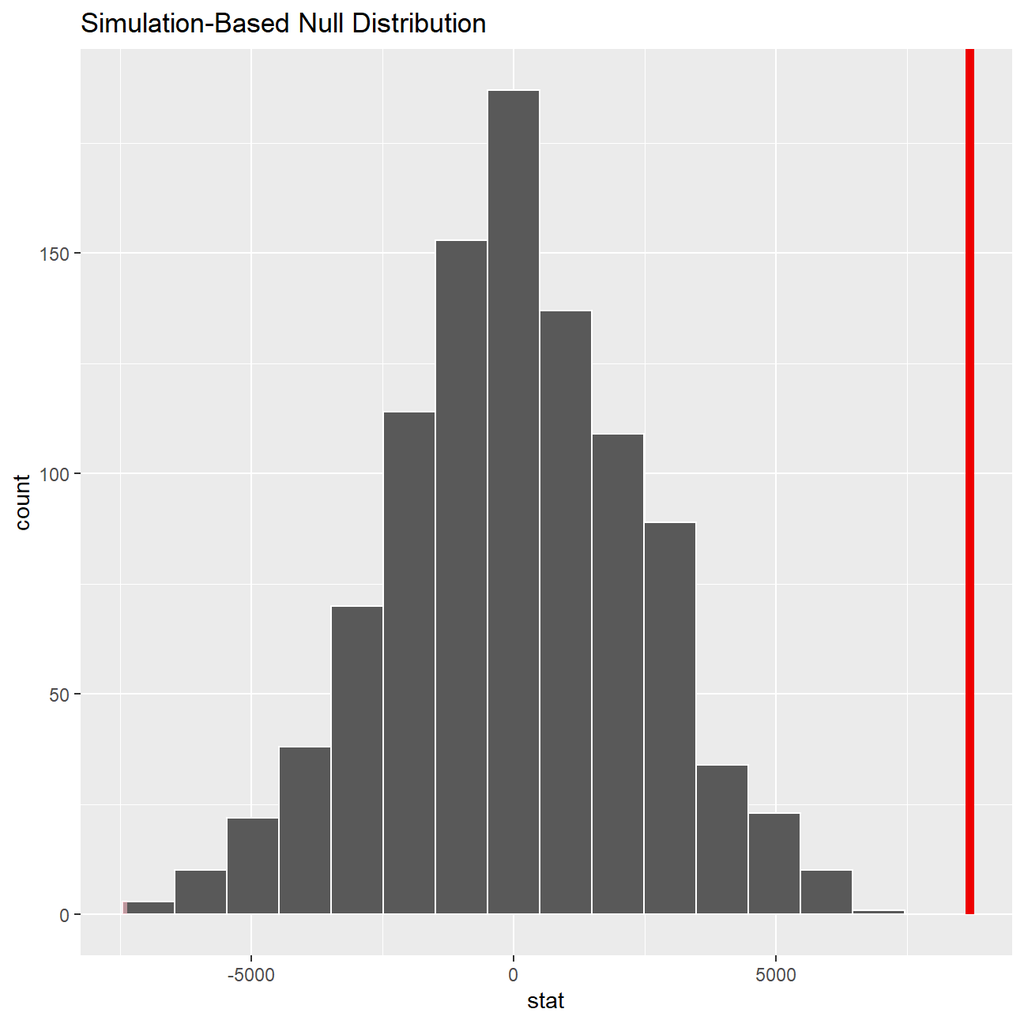

```r
null_dist_omega_1 %>% visualize() +
  shade_p_value(obs_stat = obs_diff_omega_1, direction = "two-sided")
```

```r
null_dist_omega_1 %>%
  get_p_value(obs_stat = obs_diff_omega_1, direction = "two_sided")
```

```
## # A tibble: 1 x 1
##   p_value
##     <dbl>
## 1       0
```

> What can you conclude from your analysis? A couple of sentences would be enough

Comment: Similar to what we did in the analysis of 50 male and female executives, there is a 1.26 standard deviation difference in the mean female experience of 7.38 years from the mean male experience of 21.12 years. This can again be shown with a simulation-based null distribution to verify our claims.

## 3.3 Relationship Experience - Gender?

At the board meeting, someone raised the issue that there was indeed a substantial difference between male and female salaries, but that this was attributable to other reasons such as differences in experience. A questionnaire send out to the 50 executives in the sample reveals that the average experience of the men is approximately 21 years, whereas the women only have about 7 years experience on average (see table below).

```r
# Summary Statistics of salary by gender
favstats (experience ~ gender, data=omega)
```

```
##   gender min    Q1 median   Q3 max  mean    sd  n missing
## 1 female   0  0.25    3.0 14.0  29  7.38  8.51 26       0
## 2   male   1 15.75   19.5 31.2  44 21.12 10.92 24       0
```

Based on this evidence, can you conclude that there is a significant difference between the experience of the male and female executives? Perform similar analyses as in the previous section. Does your conclusion validate or endanger your conclusion about the difference in male and female salaries?

```r
# hypothesis testing using t.test()

t.test(experience ~ gender, data = omega)
```

```
##
##  Welch Two Sample t-test
##
## data:  experience by gender
## t = -5, df = 43, p-value = 1e-05
## alternative hypothesis: true difference in means between group female and group male is not equal to 0
## 95 percent confidence interval:
##  -19.35  -8.13
## sample estimates:
## mean in group female   mean in group male
##                 7.38                21.12
```

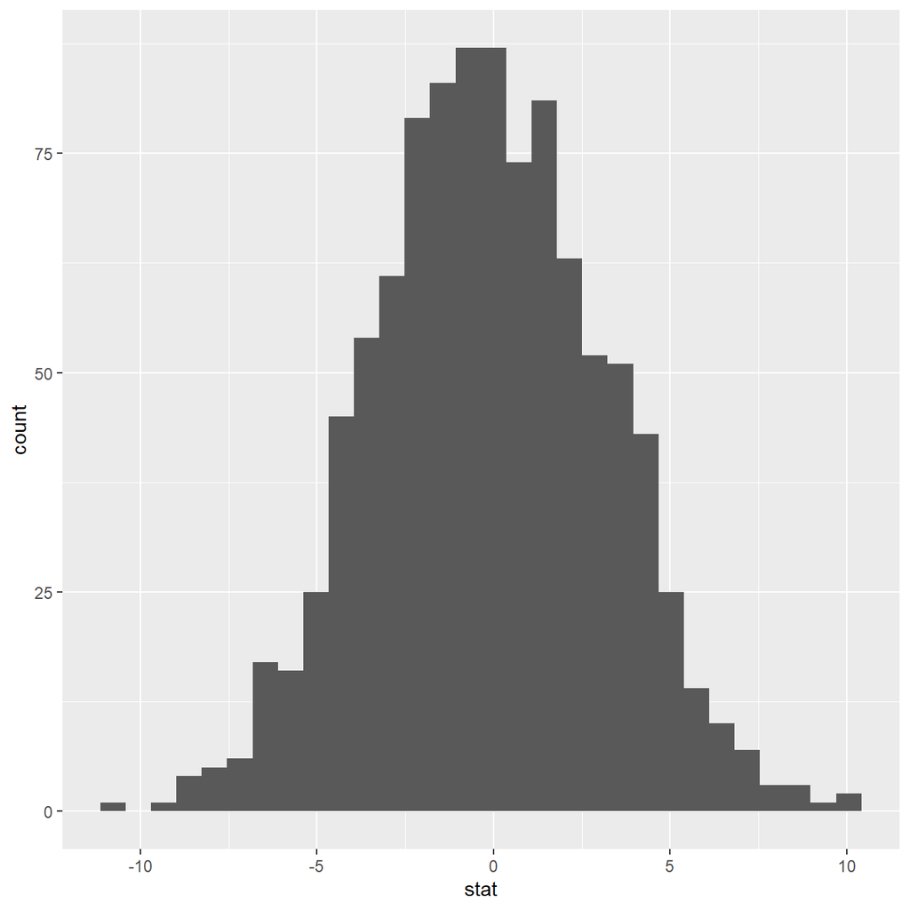

```r
# hypothesis testing using infer package
obs_diff_omega_2 <- omega %>%
  specify(experience ~ gender) %>%
  calculate(stat = "diff in means", order = c("male", "female"))

null_dist_omega_2 <- omega %>%
  # specify variables
  specify(experience ~ gender) %>%

  # assume independence, i.e, there is no difference
  hypothesize(null = "independence") %>%

  # generate 1000 reps, of type "permute"
  generate(reps = 1000, type = "permute") %>%

  # calculate statistic of difference, namely "diff in means"
  calculate(stat = "diff in means", order = c("male", "female"))

ggplot(data = null_dist_omega_2, aes(x = stat)) +
  geom_histogram()
```

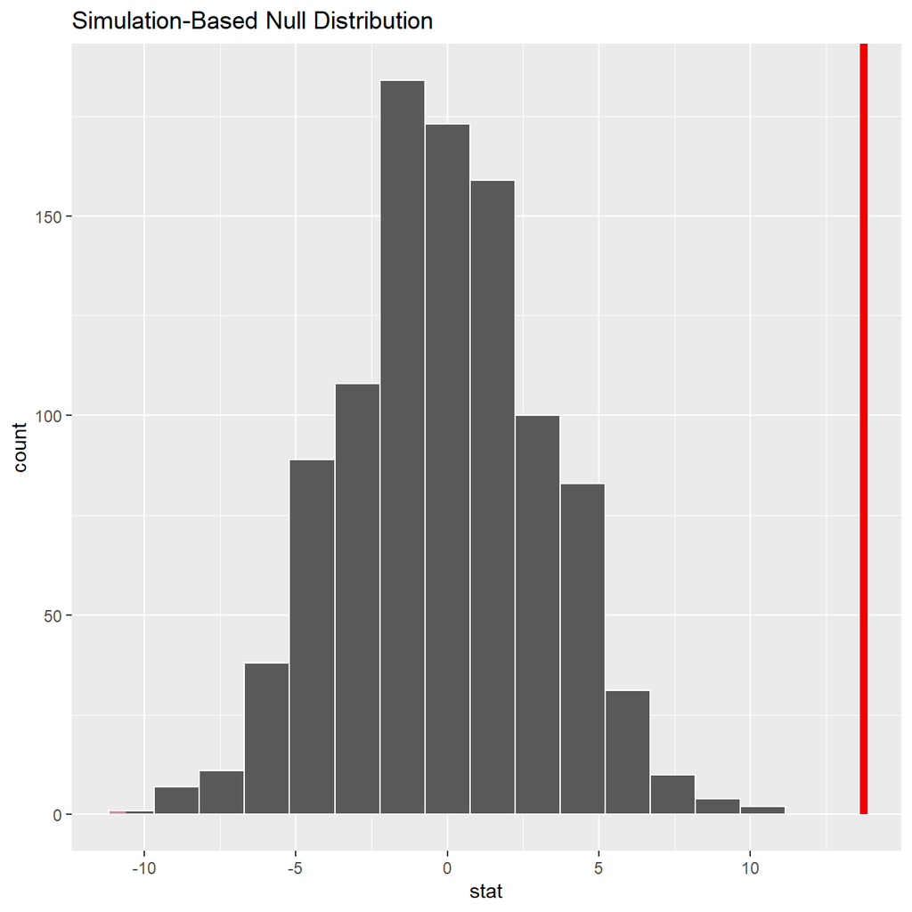

```r
null_dist_omega_2 %>% visualize() +
  shade_p_value(obs_stat = obs_diff_omega_2, direction = "two-sided")
```

```r
null_dist_omega_2 %>%
  get_p_value(obs_stat = obs_diff_omega_2, direction = "two_sided")
```

```
## # A tibble: 1 x 1
##   p_value
##     <dbl>
## 1       0
```

Comment: Having performed the simulation-based null distribution, we can again see that the p-value is very low which indicates that we again reject the null hypothesis and can conclude that there indeed is a significant difference in the experience of male and female executives. The analysis further validates what we suggested previously.

## 3.4 Relationship Salary - Experience ?

Someone at the meeting argues that clearly, a more thorough analysis of the relationship between salary and experience is required before any conclusion can be drawn about whether there is any gender-based salary discrimination in the company.

Analyse the relationship between salary and experience. Draw a scatter plot to visually inspect the data

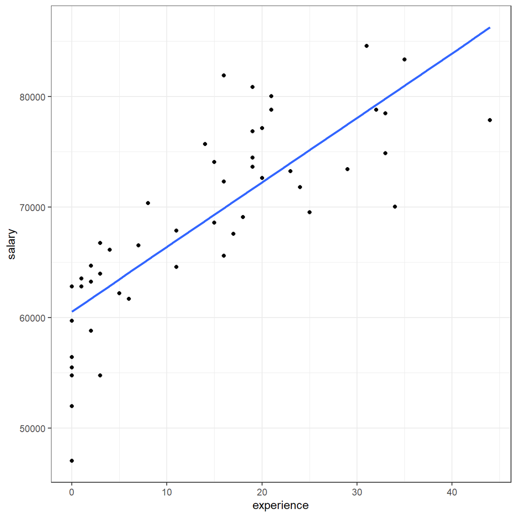

```r
ggplot(omega,aes(x = experience, y = salary)) +
  geom_point()+
  geom_smooth(method = lm,se = FALSE)+
  theme_bw()
```

## 3.5 Check correlations between the data

You can use `GGally:ggpairs()` to create a scatterplot and correlation matrix. Essentially, we change the order our variables will appear in and have the dependent variable (Y), salary, as last in our list. We then pipe the dataframe to `ggpairs()` with `aes` arguments to colour by `gender` and make ths plots somewhat transparent (`alpha = 0.3`).

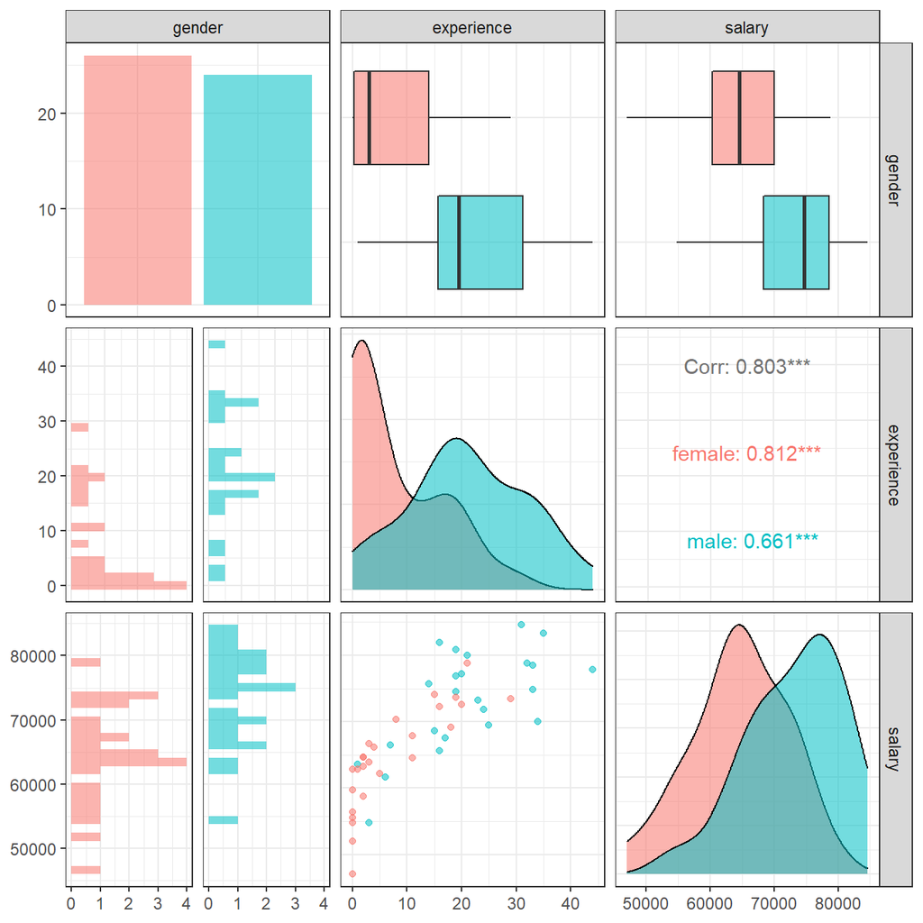

```r
omega %>%
  select(gender, experience, salary) %>% #order variables they will appear in ggpairs()
  ggpairs(aes(colour=gender, alpha = 0.3))+
  theme_bw()
```

> Look at the salary vs experience scatterplot. What can you infer from this plot? Explain in a couple of sentences

Comment: Salary and experience are quite strongly positively correlated (correlation of around 0.8), which suggests that the sex differences in salary can at least partly be explained also by the greater on average experience the male executives possess. Therefore, we must be careful when attributing sex differences simply to sexist practices within the company and look more deeply. The next step would be to understand why it is that male executives in the company possess a significantly greater number of years of experience than the female executives.

# 4 Challenge 1: Yield Curve inversion

Every so often, we hear warnings from commentators on the “inverted yield curve” and its predictive power with respect to recessions. An explainer what a [inverted yield curve is can be found here](https://www.reuters.com/article/us-usa-economy-yieldcurve-explainer/explainer-what-is-an-inverted-yield-curve-idUSKBN1O50GA). If you’d rather listen to something, here is a great podcast from [NPR on yield curve indicators](https://www.podbean.com/media/share/dir-4zgj9-6aefd11)

In addition, many articles and commentators think that, e.g., [*Yield curve inversion is viewed as a harbinger of recession*](https://www.bloomberg.com/news/articles/2019-08-14/u-k-yield-curve-inverts-for-first-time-since-financial-crisis). One can always doubt whether inversions are truly a harbinger of recessions, and [use the attached parable on yield curve inversions](https://twitter.com/5_min_macro/status/1161627360946511873).

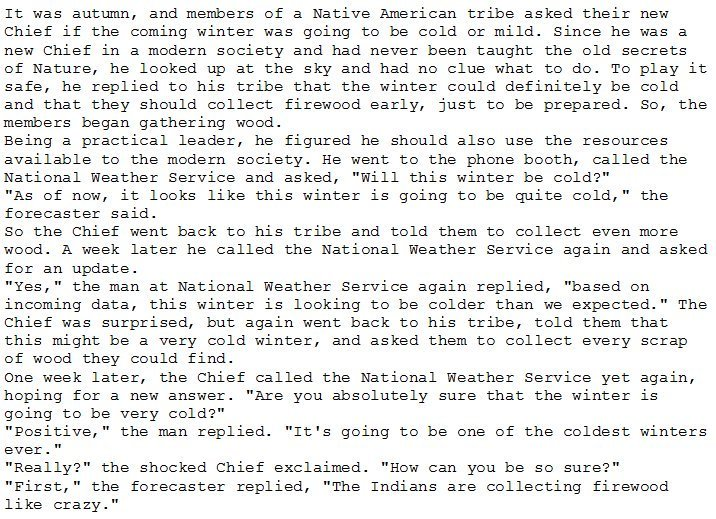

In our case we will look at US data and use the [FRED database](https://fred.stlouisfed.org/) to download historical yield curve rates, and plot the yield curves since 1999 to see when the yield curves flatten. If you want to know more, a very nice article that explains the [yield curve is and its inversion can be found here](https://fredblog.stlouisfed.org/2018/10/the-data-behind-the-fear-of-yield-curve-inversions/). At the end of this challenge you should produce this chart

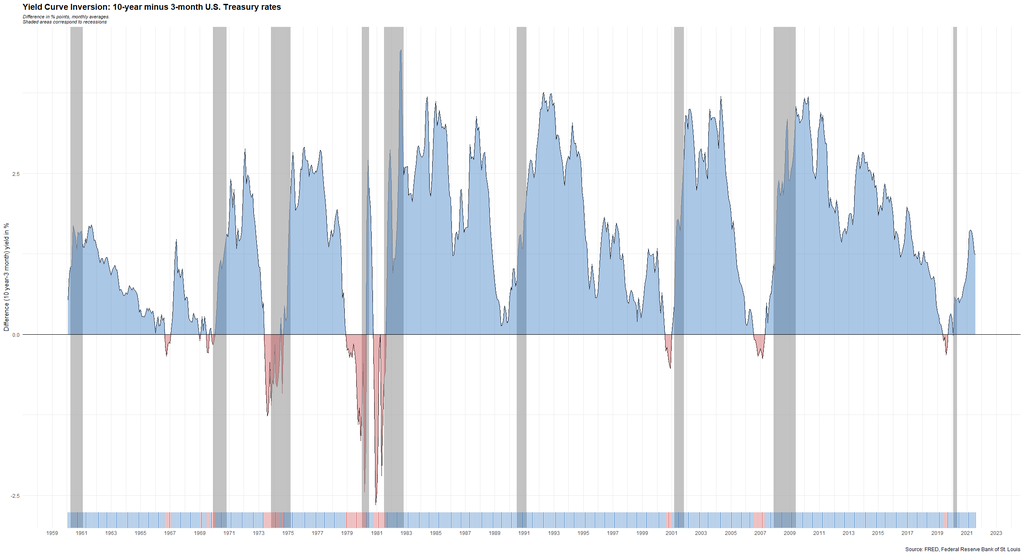

First, we will load the yield curve data file that contains data on the yield curve since 1960-01-01

```r
yield_curve <- read_csv(here::here("data", "yield_curve.csv"))

glimpse(yield_curve)
```

```
## Rows: 6,884
## Columns: 5
## $ date      <date> 1960-01-01, 1960-02-01, 1960-03-01, 1960-04-01, 1960-05-01,~
## $ series_id <chr> "TB3MS", "TB3MS", "TB3MS", "TB3MS", "TB3MS", "TB3MS", "TB3MS~
## $ value     <dbl> 4.35, 3.96, 3.31, 3.23, 3.29, 2.46, 2.30, 2.30, 2.48, 2.30, ~
## $ maturity  <chr> "3m", "3m", "3m", "3m", "3m", "3m", "3m", "3m", "3m", "3m", ~
## $ duration  <chr> "3-Month Treasury Bill", "3-Month Treasury Bill", "3-Month T~
```

```r
#skimr::skim(yield_curve$duration)

yield_curve_table <- yield_curve %>%
                     mutate(duration = factor(duration, levels= c("3-Month Treasury Bill", "6-Month Treasury Bill", "1-Year Treasury Rate","2-Year Treasury Rate", "3-Year Treasury Rate", "5-Year Treasury Rate", "7-Year Treasury Rate", "10-Year Treasury Rate","20-Year Treasury Rate", "30-Year Treasury Rate")),
                            maturity = factor(maturity, levels= c("3m", "6m", "1y", "2y","3y","5y","7y","10y","20y","30y")))

yield_curve_table
```

```
## # A tibble: 6,884 x 5
##    date       series_id value maturity duration
##    <date>     <chr>     <dbl> <fct>    <fct>
##  1 1960-01-01 TB3MS      4.35 3m       3-Month Treasury Bill
##  2 1960-02-01 TB3MS      3.96 3m       3-Month Treasury Bill
##  3 1960-03-01 TB3MS      3.31 3m       3-Month Treasury Bill
##  4 1960-04-01 TB3MS      3.23 3m       3-Month Treasury Bill
##  5 1960-05-01 TB3MS      3.29 3m       3-Month Treasury Bill
##  6 1960-06-01 TB3MS      2.46 3m       3-Month Treasury Bill
##  7 1960-07-01 TB3MS      2.3  3m       3-Month Treasury Bill
##  8 1960-08-01 TB3MS      2.3  3m       3-Month Treasury Bill
##  9 1960-09-01 TB3MS      2.48 3m       3-Month Treasury Bill
## 10 1960-10-01 TB3MS      2.3  3m       3-Month Treasury Bill
## # ... with 6,874 more rows
```

```r
yield_curve_table_1 <- yield_curve_table %>%
                       select("date", "value", "duration") %>%
                       filter(duration %in% c("3-Month Treasury Bill","10-Year Treasury Rate")) %>%
                       pivot_wider(names_from = duration , values_from = value)

colnames(yield_curve_table_1) = c("date", "three_month", "ten_year" )

yield_curve_table_1
```

```
## # A tibble: 740 x 3
##    date       three_month ten_year
##    <date>           <dbl>    <dbl>
##  1 1960-01-01        4.35     4.72
##  2 1960-02-01        3.96     4.49
##  3 1960-03-01        3.31     4.25
##  4 1960-04-01        3.23     4.28
##  5 1960-05-01        3.29     4.35
##  6 1960-06-01        2.46     4.15
##  7 1960-07-01        2.3      3.9
##  8 1960-08-01        2.3      3.8
##  9 1960-09-01        2.48     3.8
## 10 1960-10-01        2.3      3.89
## # ... with 730 more rows
```

```r
yield_curve_table_2 <- yield_curve_table_1 %>%
                       group_by(date) %>%
                       mutate(difference = ten_year-three_month,
                              up = ifelse(difference>0, difference,0),
                              down = ifelse(difference<0, difference,0),
                              color_id = if_else(difference>0,"steelblue1","tomato2"))

yield_curve_table_2
```

```
## # A tibble: 740 x 7
## # Groups:   date [740]
##    date       three_month ten_year difference    up  down color_id
##    <date>           <dbl>    <dbl>      <dbl> <dbl> <dbl> <chr>
##  1 1960-01-01        4.35     4.72       0.37  0.37     0 steelblue1
##  2 1960-02-01        3.96     4.49       0.53  0.53     0 steelblue1
##  3 1960-03-01        3.31     4.25       0.94  0.94     0 steelblue1
##  4 1960-04-01        3.23     4.28       1.05  1.05     0 steelblue1
##  5 1960-05-01        3.29     4.35       1.06  1.06     0 steelblue1
##  6 1960-06-01        2.46     4.15       1.69  1.69     0 steelblue1
##  7 1960-07-01        2.3      3.9        1.6   1.6      0 steelblue1
##  8 1960-08-01        2.3      3.8        1.5   1.5      0 steelblue1
##  9 1960-09-01        2.48     3.8        1.32  1.32     0 steelblue1
## 10 1960-10-01        2.3      3.89       1.59  1.59     0 steelblue1
## # ... with 730 more rows
```

## 4.1 Plotting the yield curve

This may seem long but it should be easy to produce the following three plots

### 4.1.1 Yields on US rates by duration since 1960

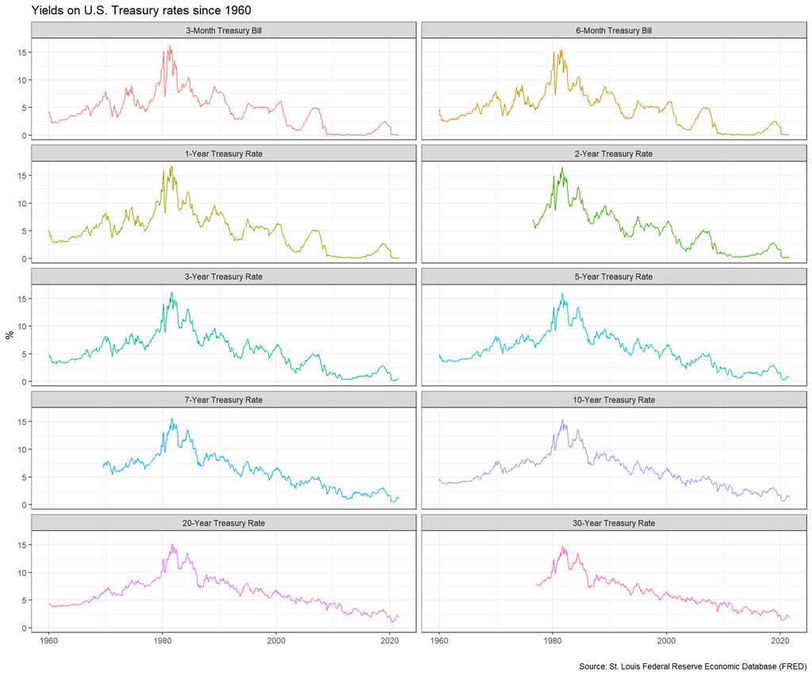

```r
ggplot(yield_curve_table, aes(x=date, y=value, color= duration)) +
  geom_line()+
  facet_wrap(~duration, ncol = 2) +
  theme_bw() +
  theme(legend.position = "none") +
  labs(title = "Yields on U.S. Treasury rates since 1960",
                 x ="",
                 y = "%",
                 caption = "Source: St. Louis Federal Reserve Economic Database (FRED)")+
  NULL
```

During the early 1990s, the economy was still in recession and the Fed decided to increase rates. However, as inflation decreased, the Fed lowered interest rates (as shown in graphs) and the US economy experienced growth until the late 1990s. During the late 1990s and early 2000s, the US experienced a deterioration in its economy that forced the Fed to lower rates further in order to stimulate growth. Finally, after the 2008-2009 Financial Crisis, the Fed started to use another policy: Quantitative Easing. Via this new policy, the Fed would not only stimulate the economy through short term rates, but also in long term rates via purchasing of long-term bonds.

### 4.1.2 Monthly yields on US rates by duration since 1999 on a year-by-year basis

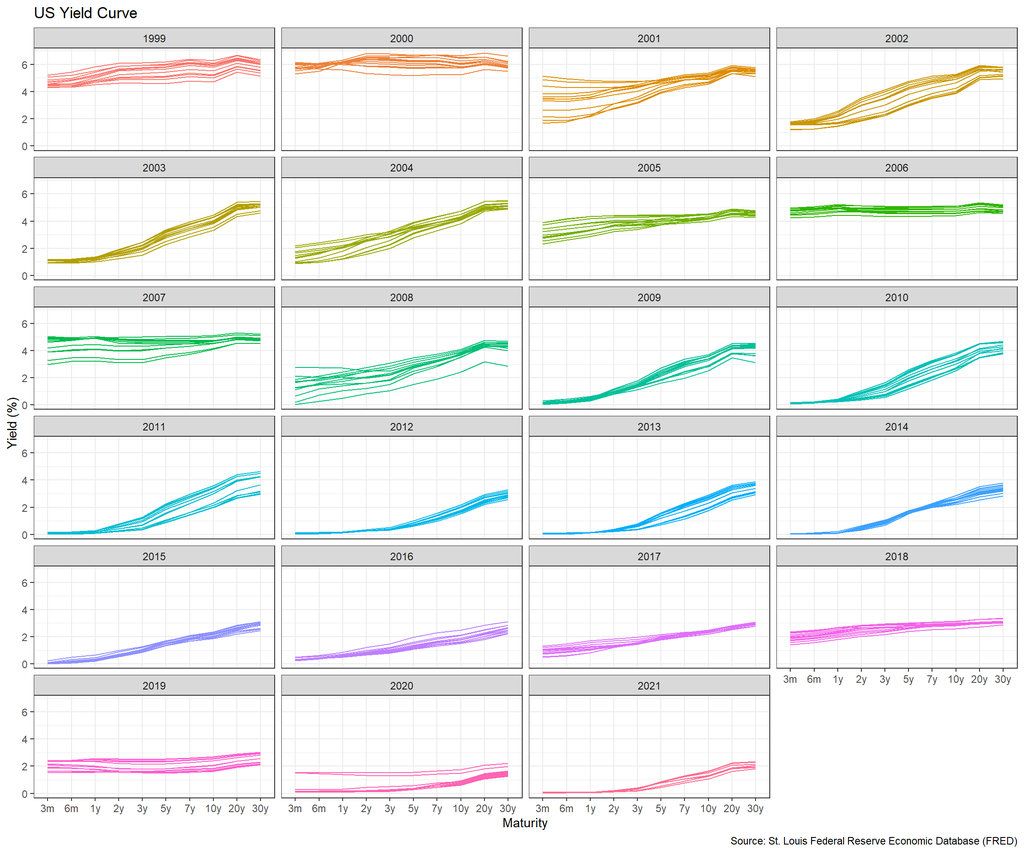

```r
yield_curve_table_3 <- yield_curve_table %>%
                       mutate(year = factor(year(date))) %>%
                       filter(date>='1999-01-01')

ggplot(yield_curve_table_3, aes(x= maturity, y= value, group = date, color= year))+
geom_path() +
facet_wrap(~year, ncol= 4)+
theme_bw() +
theme(legend.position = "none") +
labs(title = "US Yield Curve",
      x ="Maturity",
      y = "Yield (%)",
      caption = "Source: St. Louis Federal Reserve Economic Database (FRED)")+
  NULL
```

Comment: Detailed graphs provide us with a better insight of how yield curves inverted between 12-24 month before recessions. For instance, during 2000, the graph shows an inversion in the yield curve 1 year before the 2001 crisis. Furthermore, before the 2008 crisis, the yield curve flattened in 2006 and 2007. Finally, in 2019 the yield curve flattened. However, it cannot be related to the 2020 crisis, which was caused by COVID 19 pandemic global restrictions.

### 4.1.3 3-month and 10-year yields since 1999

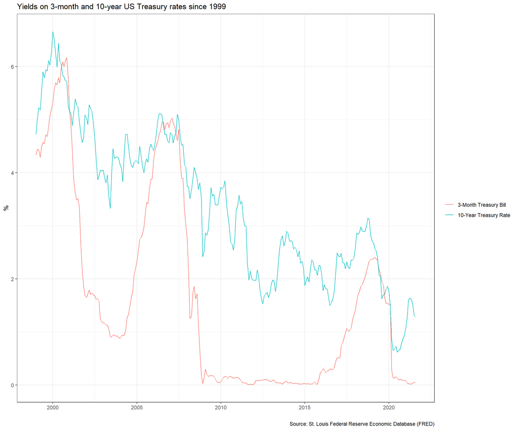

```r
yield_curve_table_4 <- yield_curve_table %>%
                       select("date", "value", "duration") %>%
                       filter( duration %in% c("3-Month Treasury Bill","10-Year Treasury Rate"))

ggplot(data = filter(yield_curve_table_4, date>= "1999-01-01"),aes(x=date, y=value, color= duration)) +
  geom_line()+
  theme_bw()+
  theme(legend.title = element_blank())+
  labs(title = "Yields on 3-month and 10-year US Treasury rates since 1999",
                 x ="",
                 y = "%",
                 caption = "Source: St. Louis Federal Reserve Economic Database (FRED)")+
  NULL
```

Comment: From the more-detailed graph we can conclude that the spread widens during economic growth times and it shortens as economic conditions deteriorate or even become negative 12 to 24 months before a recession. It is worth mentioning that the spread between 10-year and 3-month T-bills has widened as positive global expectations on economic growth are increasing, especially for the US economy, as the US population receives immunity brought by vaccines.

According to [Wikipedia’s list of recession in the United States](https://en.wikipedia.org/wiki/List_of_recessions_in_the_United_States), since 1999 there have been two recession in the US: between Mar 2001–Nov 2001 and between Dec 2007–June 2009. Does the yield curve seem to flatten before these recessions? Can a yield curve flattening really mean a recession is coming in the US? Since 1999, when did short-term (3 months) yield more than longer term (10 years) debt?

The code below creates a dataframe with all US recessions since 1946

```r
# get US recession dates after 1946 from Wikipedia
# https://en.wikipedia.org/wiki/List_of_recessions_in_the_United_States

recessions <- tibble(
  from = c("1948-11-01", "1953-07-01", "1957-08-01", "1960-04-01", "1969-12-01", "1973-11-01", "1980-01-01","1981-07-01", "1990-07-01", "2001-03-01", "2007-12-01","2020-02-01"),
  to = c("1949-10-01", "1954-05-01", "1958-04-01", "1961-02-01", "1970-11-01", "1975-03-01", "1980-07-01", "1982-11-01", "1991-03-01", "2001-11-01", "2009-06-01", "2020-04-30")
  )  %>%
  mutate(From = ymd(from),
         To=ymd(to),
         duration_days = To-From)


recessions
```

```
## # A tibble: 12 x 5
##    from       to         From       To         duration_days
##    <chr>      <chr>      <date>     <date>     <drtn>
##  1 1948-11-01 1949-10-01 1948-11-01 1949-10-01 334 days
##  2 1953-07-01 1954-05-01 1953-07-01 1954-05-01 304 days
##  3 1957-08-01 1958-04-01 1957-08-01 1958-04-01 243 days
##  4 1960-04-01 1961-02-01 1960-04-01 1961-02-01 306 days
##  5 1969-12-01 1970-11-01 1969-12-01 1970-11-01 335 days
##  6 1973-11-01 1975-03-01 1973-11-01 1975-03-01 485 days
##  7 1980-01-01 1980-07-01 1980-01-01 1980-07-01 182 days
##  8 1981-07-01 1982-11-01 1981-07-01 1982-11-01 488 days
##  9 1990-07-01 1991-03-01 1990-07-01 1991-03-01 243 days
## 10 2001-03-01 2001-11-01 2001-03-01 2001-11-01 245 days
## 11 2007-12-01 2009-06-01 2007-12-01 2009-06-01 548 days
## 12 2020-02-01 2020-04-30 2020-02-01 2020-04-30  89 days
```

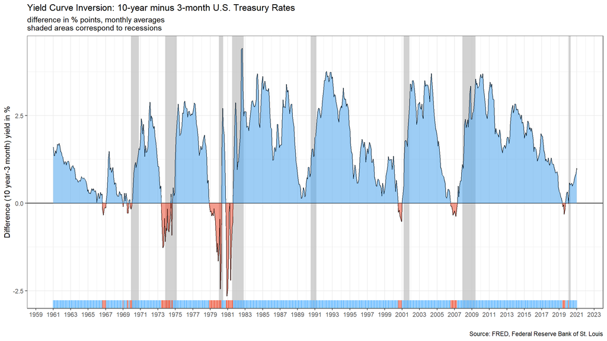

```r
library(scales)

treasury_rate_graph<- ggplot(yield_curve_table_2, aes(x = date, y= difference)) +
        geom_rect(data= filter(recessions, From > "1960-01-01"),inherit.aes = F, mapping= aes(xmin= From,xmax= To, ymin = -Inf, ymax = Inf), fill = "grey75", alpha=0.7) +
        geom_line(color= "black") +
        geom_hline(yintercept=0,color = "black") +
        geom_ribbon(aes(ymin=up,ymax=0),fill="steelblue2",alpha=0.6)  +
        geom_ribbon(aes(ymin=0,ymax=down),fill="tomato2",alpha=0.6)+
        theme_bw() +
        geom_rug(mapping = aes(color = color_id), sides= "b")+
        scale_color_manual(values = c("steelblue1","tomato2")) +
        labs(title = "Yield Curve Inversion: 10-year minus 3-month U.S. Treasury Rates",
                 subtitle = "difference in % points, monthly averages
shaded areas correspond to recessions",
                 x ="",
                 y = "Difference (10 year-3 month) yield in %",
                 caption = "Source: FRED, Federal Reserve Bank of St. Louis") +
         theme(legend.position = "none") +
         scale_x_date(date_breaks = "2 year", date_labels ="%Y", limits = c(as.Date("1961-01-01"),as.Date("2021-01-12")))+
         NULL
treasury_rate_graph
```

Comment: The Yield Curve (YC) is defined as the difference (spread) between the yield on 10-year T-Bonds and yield on 3-month (or 1-year) T-Bonds. In simpler terms, YC depicts a relationship between short-term and long-term rates of most safe financial securities: Treasury Bonds. During the last 60 years, it has been interesting that mostly all times that YC inverted (negative spread), after 12-24 months, a recession began in the US (except for one occasion). The graph shows that after a period of inverted YC (red colour), a recession (shadow area) followed (except in the 1960s). Nevertheless, the inverted Yield Curve cannot predict with certainty if it would occur a recession and the depth of the recession. For instance, the 2020 Recession was caused by COVID 19 Pandemic. Nevertheless, the graph shows that there was an inverted YC before the 2020 recession. Therefore, one must be careful when concluding economic phenomena just based on a chart.

# 5 Challenge 2: GDP components over time and among countries

At the risk of oversimplifying things, the main components of gross domestic product, GDP are personal consumption (C), business investment (I), government spending (G) and net exports (exports - imports). You can read more about GDP and the different approaches in calculating at the [Wikipedia GDP page](https://en.wikipedia.org/wiki/Gross_domestic_product).

The GDP data we will look at is from the [United Nations’ National Accounts Main Aggregates Database](https://unstats.un.org/unsd/snaama/Downloads), which contains estimates of total GDP and its components for all countries from 1970 to today. We will look at how GDP and its components have changed over time, and compare different countries and how much each component contributes to that country’s GDP. The file we will work with is [GDP and its breakdown at constant 2010 prices in US Dollars](http://unstats.un.org/unsd/amaapi/api/file/6) and it has already been saved in the Data directory. Have a look at the Excel file to see how it is structured and organised

```r
UN_GDP_data  <-  read_excel(here::here("data", "Download-GDPconstant-USD-countries.xls"), # Excel filename
                sheet="Download-GDPconstant-USD-countr", # Sheet name
                skip=2) # Number of rows to skip
```

The first thing you need to do is to tidy the data, as it is in wide format and you must make it into long, tidy format. Please express all figures in billions (divide values by `1e9`, or $10^9$), and you want to rename the indicators into something shorter.

```r
library(dplyr)
library(R.utils)
library(readr)
library(ggtext)
library(scales)
library(lubridate)

tidy_GDP_data <- UN_GDP_data %>%
  subset(select = -c(CountryID)) %>%
  pivot_longer(cols = 3:50,
               names_to = "year",
               values_to = "value") %>%
  mutate(value = value/1e9)

glimpse(tidy_GDP_data)
```

```
## Rows: 176,880
## Columns: 4
## $ Country       <chr> "Afghanistan", "Afghanistan", "Afghanistan", "Afghanista~
## $ IndicatorName <chr> "Final consumption expenditure", "Final consumption expe~
## $ year          <chr> "1970", "1971", "1972", "1973", "1974", "1975", "1976", ~
## $ value         <dbl> 5.56, 5.33, 5.20, 5.75, 6.15, 6.32, 6.37, 6.90, 7.09, 6.~
```

```r
# Let us compare GDP components for these 3 countries
country_list <- c("United States","India", "Germany")

tidy_GDP_data$IndicatorName[tidy_GDP_data$IndicatorName == "Exports of goods and services"] <- "Exports"
tidy_GDP_data$IndicatorName[tidy_GDP_data$IndicatorName == "General government final consumption expenditure"] <- "Government expenditure"
tidy_GDP_data$IndicatorName[tidy_GDP_data$IndicatorName == "Household consumption expenditure (including Non-profit institutions serving households)"] <- "Household expenditure"
tidy_GDP_data$IndicatorName[tidy_GDP_data$IndicatorName == "Imports of goods and services"] <- "Imports"
tidy_GDP_data$IndicatorName[tidy_GDP_data$IndicatorName == "Gross Domestic Product (GDP)"] <- "GDP"

country_list_GDP_all <- subset(tidy_GDP_data, Country == "United States"|
                                 Country == "India"|
                                 Country == "Germany")
country_list_GDP_all
```

```
## # A tibble: 2,448 x 4
##    Country IndicatorName                 year  value
##    <chr>   <chr>                         <chr> <dbl>
##  1 Germany Final consumption expenditure 1970  1152.
##  2 Germany Final consumption expenditure 1971  1218.
##  3 Germany Final consumption expenditure 1972  1282.
##  4 Germany Final consumption expenditure 1973  1329.
##  5 Germany Final consumption expenditure 1974  1345.
##  6 Germany Final consumption expenditure 1975  1398.
##  7 Germany Final consumption expenditure 1976  1450.
##  8 Germany Final consumption expenditure 1977  1504.
##  9 Germany Final consumption expenditure 1978  1560.
## 10 Germany Final consumption expenditure 1979  1614.
## # ... with 2,438 more rows
```

```r
country_list_GDP_components<-subset(country_list_GDP_all, IndicatorName == "Gross capital formation" |
                             IndicatorName == "Exports" |
                             IndicatorName == "Government expenditure" |
                             IndicatorName == "Household expenditure" |
                             IndicatorName == "Imports") %>%
                             mutate(IndicatorName = factor(IndicatorName, levels = c("Gross capital formation", "Exports", "Government expenditure", "Household expenditure", "Imports")))
country_list_GDP_components
```

```
## # A tibble: 720 x 4
##    Country IndicatorName         year  value
##    <chr>   <fct>                 <chr> <dbl>
##  1 Germany Household expenditure 1970   872.
##  2 Germany Household expenditure 1971   919.
##  3 Germany Household expenditure 1972   969.
##  4 Germany Household expenditure 1973   997.
##  5 Germany Household expenditure 1974   995.
##  6 Germany Household expenditure 1975  1032.
##  7 Germany Household expenditure 1976  1076.
##  8 Germany Household expenditure 1977  1122.
##  9 Germany Household expenditure 1978  1162.
## 10 Germany Household expenditure 1979  1200.
## # ... with 710 more rows
```

```r
# Create a subset to include only the three countries

country_list_GDP <- subset(country_list_GDP_components, Country %in% c(country_list))
```

First, can you produce this plot?

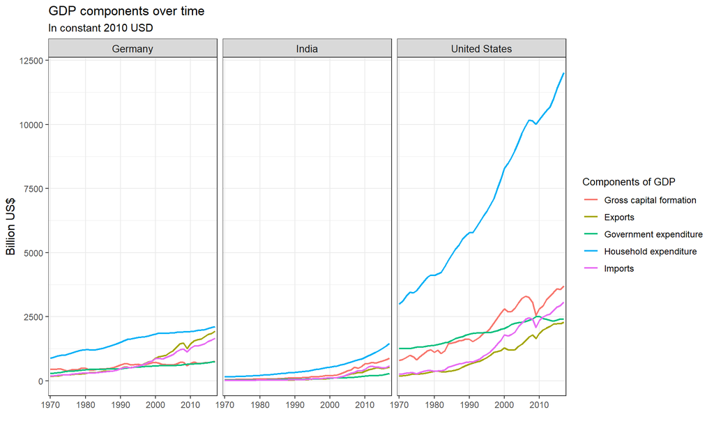

```r
country_list_GDP_plot<- ggplot(country_list_GDP, aes(x = year, y = value, group=IndicatorName, colour=IndicatorName)) +
                        geom_path(size = 0.8) +
                        facet_wrap(~factor(country_list_GDP$Country, levels = unique(country_list_GDP$Country)))+
                        theme_bw()+
                        scale_x_discrete(breaks = c(1970, 1980, 1990, 2000, 2010)) +
                        labs(title = "GDP components over time",
                             subtitle = "In constant 2010 USD",
                             x = " ", y= "Billion US$",
                             color='Components of GDP') +
                        theme(#plot.title = element_text(size=20, face = "bold"),
                              #plot.subtitle = element_markdown(size= 15),
                              legend.title = element_text(size=10),
                              legend.text = element_text(size=9),
                              strip.text = element_text(size=10),
                              axis.title.y = element_text(size = 12),
                              axis.text.y = element_text(size = 9),
                              axis.text.x = element_text(size = 9)) +
                           NULL

country_list_GDP_plot
```

Secondly, recall that GDP is the sum of Household Expenditure (Consumption *C*), Gross Capital Formation (business investment *I*), Government Expenditure (G) and Net Exports (exports - imports). Even though there is an indicator `Gross Domestic Product (GDP)` in your dataframe, I would like you to calculate it given its components discussed above.

```r
GDP_breakdown <- country_list_GDP %>%
  pivot_wider(names_from = IndicatorName, values_from = value) %>%
  mutate(`Net exports` = Exports - Imports,
         GDP = `Gross capital formation`+`Household expenditure`+`Government expenditure`+`Net exports`,
         `Government Expenditure` = `Government expenditure`/GDP,
         `Household Expenditure` = `Household expenditure`/GDP,
         `Gross Capital Formation` = `Gross capital formation`/GDP,
         `Net Exports` = `Net exports`/GDP) %>%
  select(Country, year,GDP,`Government Expenditure`,`Household Expenditure`,`Gross Capital Formation`,`Net Exports`)
```

> What is the % difference between what you calculated as GDP and the GDP figure included in the dataframe?

Comment: For Germany and the US, there is on average a positive % difference, while for India it is negative. This may be caused by the strength of local currencies against the USD. An important factor that the UN used to calculate the composition of GDP is exchange rate. Furthermore, using a unique exchange rate for 1 year may not be entirely justified and may cause differences between GDP figure and calculated GDP.

```r
GDP_compare <- subset(country_list_GDP_all, IndicatorName == "GDP") %>%
  pivot_wider(names_from = IndicatorName, values_from = value) %>%
  add_column(calculated_GDP = GDP_breakdown$GDP) %>%
  mutate(difference = ((calculated_GDP-GDP)/calculated_GDP),
         difference = scales::percent(difference))

GDP_compare
```

```
## # A tibble: 144 x 5
##    Country year    GDP calculated_GDP difference
##    <chr>   <chr> <dbl>          <dbl> <chr>
##  1 Germany 1970  1534.          1581. 2.9411489%
##  2 Germany 1971  1582.          1638. 3.4186469%
##  3 Germany 1972  1650.          1709. 3.4345346%
##  4 Germany 1973  1729.          1779. 2.8384274%
##  5 Germany 1974  1744.          1775. 1.7494124%
##  6 Germany 1975  1729.          1780. 2.8439266%
##  7 Germany 1976  1815.          1866. 2.7550360%
##  8 Germany 1977  1876.          1927. 2.6906752%
##  9 Germany 1978  1932.          1991. 2.9584940%
## 10 Germany 1979  2012.          2081. 3.3270997%
## # ... with 134 more rows
```

> Replicate the second plot

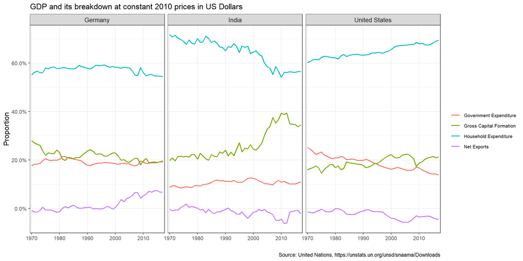

```r
GDP_breakdown_data <- GDP_breakdown %>%
  subset(select = -c(GDP)) %>%
pivot_longer(cols = 3:6,
               names_to = "component",
               values_to = "proportion")

GDP_breakdown_plot <-
  ggplot(GDP_breakdown_data, aes(x = year, y = proportion, group=component, colour=component)) +
  geom_line(size = 0.8) +
  facet_wrap(~factor(GDP_breakdown_data$Country, levels = unique(GDP_breakdown_data$Country)))+
  theme_bw()+
  scale_y_continuous(labels = scales::percent_format(accuracy = 0.1))+
  scale_x_discrete(breaks = c(1970, 1980, 1990, 2000, 2010)) +
  labs(title = "GDP and its breakdown at constant 2010 prices in US Dollars",
       x = " ",
       y= "Proportion",
       color='Components of GDP',
       caption= "Source: United Nations, https://unstats.un.org/unsd/snaama/Downloads") +
  theme(#plot.title = element_text(size=12, face = "bold"),
        legend.title = element_blank(),
        legend.text = element_text(size=8),
        strip.text = element_text(size=10),
        axis.title.y = element_text(size = 12),
        axis.text.y = element_text(size = 9),
        axis.text.x = element_text(size = 9)) +
     NULL

GDP_breakdown_plot
```

> What is this last chart telling you? Can you explain in a couple of paragraphs the different dynamic among these three countries?

Comment: In the case of Germany, from 1970 onwards, there is a clear positive trend in net exports and negative trend in household consumption. Positive net exports is a clear sign that Germany is relying a big proportion of its economy on exports, and it makes sense given the industrialization produced in the last 20 years in that country. On the other hand, household consumption has declined slightly, making Germany a less dependent country of consumer momentum.

In the case of India, there is a clear positive trend in gross capital formation that is coherent with the last 2 decades of constant growth in India’s production capabilities. As a consequence, India is less dependent on internal consumer momentum and it is following China’s steps in becoming a global industrial producer.

Finally, in the US consumption has become more relevant as years passed, which makes the US economy more dependent on consumer’s confidence. On the other hand, Government Expenditure contribution to GDP has been declining and that may be the reason why the US is now aiming to increase its Government Expenditure in national infrastructure in order to close the infra gap not pursued by previous governments and that is reflected in GDP’s composition.

> If you want to, please change `country_list <- c("United States","India", "Germany")` to include your own country and compare it with any two other countries you like

```r
# Create a new list of the three countries we selected
country_list_new <- c("China","Peru", "Spain")

country_list_GDP_all_new <- subset(tidy_GDP_data, Country == "China"|
                                 Country == "Peru"|
                                 Country == "Spain")

country_list_GDP_components<-subset(country_list_GDP_all_new, IndicatorName == "Gross capital formation" |
                             IndicatorName == "Exports" |
                             IndicatorName == "Government expenditure" |
                             IndicatorName == "Household expenditure" |
                             IndicatorName == "Imports") %>%
                             mutate(IndicatorName = factor(IndicatorName, levels = c("Gross capital formation", "Exports", "Government expenditure", "Household expenditure", "Imports")))
country_list_GDP_components
```

```
## # A tibble: 720 x 4
##    Country IndicatorName         year  value
##    <chr>   <fct>                 <chr> <dbl>
##  1 China   Household expenditure 1970   108.
##  2 China   Household expenditure 1971   112.
##  3 China   Household expenditure 1972   118.
##  4 China   Household expenditure 1973   127.
##  5 China   Household expenditure 1974   129.
##  6 China   Household expenditure 1975   135.
##  7 China   Household expenditure 1976   139.
##  8 China   Household expenditure 1977   143.
##  9 China   Household expenditure 1978   151.
## 10 China   Household expenditure 1979   158.
## # ... with 710 more rows
```

```r
# Subset of data of the three countries
country_list_GDP_new <- subset(country_list_GDP_components, Country %in% c(country_list_new))
country_list_GDP_new
```

```
## # A tibble: 720 x 4
##    Country IndicatorName         year  value
##    <chr>   <fct>                 <chr> <dbl>
##  1 China   Household expenditure 1970   108.
##  2 China   Household expenditure 1971   112.
##  3 China   Household expenditure 1972   118.
##  4 China   Household expenditure 1973   127.
##  5 China   Household expenditure 1974   129.
##  6 China   Household expenditure 1975   135.
##  7 China   Household expenditure 1976   139.
##  8 China   Household expenditure 1977   143.
##  9 China   Household expenditure 1978   151.
## 10 China   Household expenditure 1979   158.
## # ... with 710 more rows
```

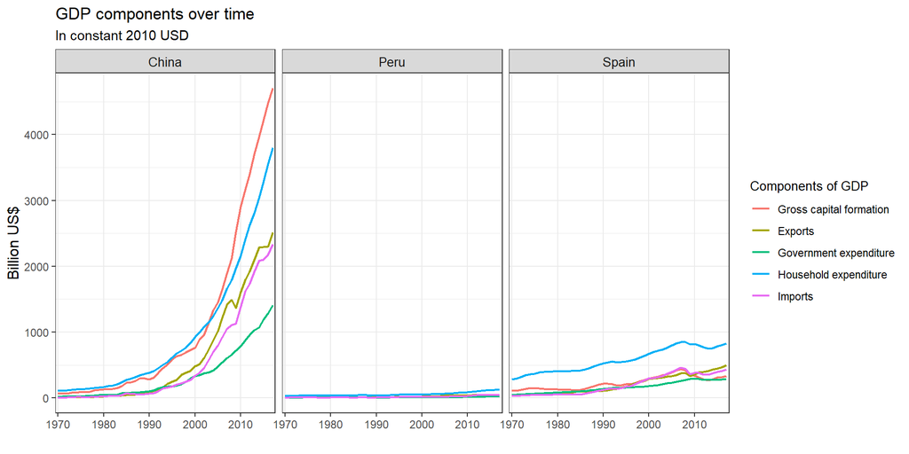

```r
# Plot the GDP components over time for the three countries
country_list_GDP_plot_new <-
  ggplot(country_list_GDP_new, aes(x = year, y = value, group=IndicatorName, colour=IndicatorName)) +
  geom_path(size = 0.8) +
  facet_wrap(~factor(Country))+
  theme_bw()+
  scale_x_discrete(breaks = c(1970, 1980, 1990, 2000, 2010)) +
  labs(title = "GDP components over time",
       subtitle = "In constant 2010 USD",
       x = " ", y= "Billion US$",
       color='Components of GDP') +
  theme(#plot.title = element_text(size=20, face = "bold"),
                              #plot.subtitle = element_markdown(size= 15),
                              legend.title = element_text(size=10),
                              legend.text = element_text(size=8.5),
                              strip.text = element_text(size=10),
                              axis.title.y = element_text(size = 12),
                              axis.text.y = element_text(size = 9),
                              axis.text.x = element_text(size = 9)) +
                           NULL

country_list_GDP_plot_new
```

Comment: Evolution of GDP components graph for China shows the exponential growth that the Chinese economy has experienced in the last 40 years. All components of China’s GDP experienced growth and we can appreciate that gross capital formation contributes the most to the economy, a fact that makes sense as China is the most relevant industrial producer for the entire world.

Regarding Peru GDP’s components, most components grew slightly as a result of the different economic crisis that Peru suffered from 1980 to 2000. From 2000 onwards, Peru’s economy grew but not as much as China’s economy.

Finally, Spain’s economy experienced growth especially in its household consumption component. Nevertheless, the rest of the components have been relatively flat, a situation that can be caused by slow growth in the Spanish economy in the last 2 decades.

```r
# Calculate GDP and % of each component
GDP_breakdown_new <- country_list_GDP_new %>%
  pivot_wider(names_from = IndicatorName, values_from = value) %>%
  mutate(`Net exports` = Exports - Imports,
         GDP = `Gross capital formation`+`Household expenditure`+`Government expenditure`+`Net exports`,
         `Government Expenditure` = `Government expenditure`/GDP,
         `Household Expenditure` = `Household expenditure`/GDP,
         `Gross Capital Formation` = `Gross capital formation`/GDP,
         `Net Exports` = `Net exports`/GDP) %>%
  select(Country, year,GDP,`Government Expenditure`,`Household Expenditure`,`Gross Capital Formation`,`Net Exports`)
```

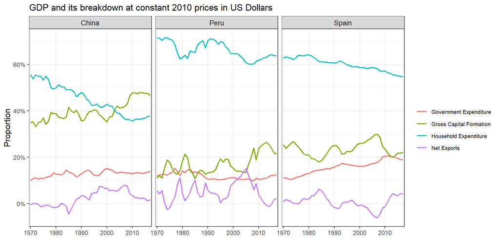

```r
# Plot GDP breakdown of the three countries (%)
GDP_breakdown_data_new <- GDP_breakdown_new %>%
  subset(select = -c(GDP)) %>%
pivot_longer(cols = 3:6,
               names_to = "component",
               values_to = "proportion")

GDP_breakdown_plot_new <-
  ggplot(GDP_breakdown_data_new, aes(x = year, y = proportion, group=component, colour=component)) +
  geom_line(size = 0.8) +
  facet_wrap(~factor(Country))+
  theme_bw()+
  scale_y_continuous(labels = scales::percent)+
  scale_x_discrete(breaks = c(1970, 1980, 1990, 2000, 2010)) +
  labs(title = "GDP and its breakdown at constant 2010 prices in US Dollars",
       x = " ", y= "Proportion",
       color='Components of GDP') +
  theme(#plot.title = element_text(size=12, face = "bold"),
        legend.title = element_blank(),
        legend.text = element_text(size=8),
        strip.text = element_text(size=10),
        axis.title.y = element_text(size = 12),
        axis.text.y = element_text(size = 9),
        axis.text.x = element_text(size = 9)) +
     NULL

GDP_breakdown_plot_new
```

Comment: The Chinese economy has become less dependent on household consumption, becoming an economy in constant growth supported by investment in increasing production capabilities.

The Peruvian economy is still dependent on internal demand. We can appreciate that there has been an increasing importance of the gross capital formation component, which is coherent with the economic evolution of an underdeveloped economy.

Finally, Spain has experienced a decline in the relevance of gross capital formation. Lower investments can be explained by recent economic downturns in Spain and the lower confidence of international investors in Spanish economy.

# 6 Details

- Who did you collaborate with: NA
- Approximately how much time did you spend on this problem set: 15 hours
- What, if anything, gave you the most trouble: NA